# Testing the triangulate package for TAAR1 agonists in schizophrenia

GALENOS animal-human triangulation workflow with transparent local adaptations

Alexandra Bannach-Brown

13 May 2026

# 1 Purpose of this document

The aim of this document is to test the `triangulate` R package with a GALENOS use-case, in the triangulation of animal and human evidence on trace amine-associated receptor 1 (TAAR1) agonists for psychosis/schizophrenia.

The clinical and animal context comes from the GALENOS living systematic review on TAAR1 agonism for psychosis and the subsequent GALENOS triangulation work. The TAAR1 review reports that ulotaront and ralmitaront showed few differences versus placebo for overall symptoms in adults with acute schizophrenia, with four studies and 1291 participants giving an SMD around 0.15 with 95% CI roughly -0.05 to 0.34. The triangulation paper describes animal evidence suggesting reduced pro-psychotic drug-induced locomotor activity, while also emphasising risk of bias, reproducibility, translational validity, and interpretability challenges.

Useful sources:

- `triangulate` package documentation - Shapland et al 2024: https://mrcieu.r-universe.dev/triangulate
- “triangulate” preprint - Shapland et al 2024: https://www.medrxiv.org/content/10.1101/2024.09.20.24314046v1.full.pdf
- `triangulate` reference manual: https://mrcieu.r-universe.dev/triangulate/doc/manual.html
- TAAR1 living systematic review - Siafis et al 2024: https://pmc.ncbi.nlm.nih.gov/articles/PMC11258611/
- GALENOS TAAR1 triangulation paper - Smith et al 2025: https://www.cambridge.org/core/journals/the-british-journal-of-psychiatry/article/triangulating-evidence-from-the-galenos-living-systematic-review-on-trace-amineassociated-receptor-1-taar1-agonists-in-psychosis/B5202B48429F1E700F5274724FB176C0
- GALENOS GATE approach paper - Smith et al 2025: https://www.cambridge.org/core/journals/the-british-journal-of-psychiatry/article/galenos-approach-to-triangulating-evidence-gate-transforming-the-landscape-of-psychiatric-research/94A657ABCCF4755661502785529339E0

## 1.1 How this R Markdown file uses the script

The full source code for this workflow is publicly available on GitHub: https://github.com/abannachbrown/TAAR1agonist_triangulatePackage_demo

The code chunks below are pulled directly from `taar1-agonists.R` with `readLines()`. This avoids having two independent copies of the same analysis code that could become inconsistent. When this file is knitted, the HTML runs the full workflow. Code is hidden by default to make the report easier to read, but every code chunk can be opened with the “Show code” button. The sourced helper files are shown in an appendix at the end. The most important local helper is `Functions/BiasCorrect_robviz.R`, which contains the amended copy of the plotting function used instead of the package plotting wrapper.

# 2 Package workflow being tested

The `triangulate` documentation describes a workflow in which study-level effect estimates are combined with structured risk-of-bias and indirectness judgements. The core functions used here are:

- `tri_to_long()`: converts wide domain columns such as `d1j`, `d1t`, `d1d` into one row per domain.
- `tri_dat_check()`: checks that required columns are present.
- `tri_absolute_direction()`: converts relative qualitative directions such as “Away from null” or “Towards null” into absolute directions usable by the adjustment code.
- `tri_append_bias()`: joins additive and proportional bias prior parameters to each risk-of-bias domain.
- `tri_append_indirect()`: joins indirectness prior parameters to indirectness domains.
- `tri_prep_data_direct_scale()`: local transparent replacement for `tri_prep_data()` that aggregates bias and indirectness information and calculates `yi_adj` and `vi_adj` using direct-scale proportional factors.
- `tri_plot_bias_direction()`: package plotting approach for original and bias-adjusted estimates. In this project we instead source a local amended version of the internal plotting function, because the TAAR1 use case needs D1-D10 animal risk-of-bias domains, SMD-scale plotting without `exp()`, and external subgroup models.

## 2.1 Important adaptations for the TAAR1 use case

This analysis is not a direct copy of the package example because the TAAR1 data have features that the example plotting function did not fully cover.

1. Animal data are displayed as 17 drug-level rows, but the subgroup summary should use the original 188-effect multivariate model.
2. Animal risk of bias has 10 SYRCLE-style domains, so the plot must display D1-D10 rather than D1-D7.
3. The endpoint is SMD, so original and adjusted values must remain on the SMD scale. The plotting function therefore uses `identity` rather than `exp`.
4. The package’s default proportional-bias adjustment was not used for the final estimates, because it converts proportional priors through lognormal/exponential moments and then rescales the variance in a way that is not appropriate for this direct SMD-scale application.
5. A local transparent replacement, `tri_prep_data_direct_scale()`, is used instead. It applies proportional bias as a direct factor, $B = 1 + p$, and uses the variance formula shown below.
6. Animal and human bias priors are defined separately because the empirical uncertainty anchors differ.
7. No bespoke indirectness assessments are currently available in these files, so explicit “None” indirectness rows are created and still passed through the documented package functions.
8. The plotting helper has been locally amended to accept externally fitted subgroup summaries. This allows the animal summary to come from `metafor::rma.mv()` and the human summary to come from `meta::metagen()`.

## 2.2 Local changes to proportional-bias adjustment

This is the most important analytical change from the package default. It is described here in three steps: how the issue was noticed, what was changed in the local code, and how the adjusted error bars can be interpreted.

### 2.2.1 1. How the issue was noticed

The issue was noticed because some bias-adjusted confidence intervals became much narrower than expected in a workflow using SMDs on the identity scale.

Inspection of the default package calculation showed that proportional bias parameters were converted using lognormal/exponential scaling. This is appropriate for ratio measures such as odds ratios, risk ratios, or hazard ratios, where effects are commonly analysed on a log scale and then exponentiated for interpretation. It is not appropriate for this application because the outcome is an SMD and the priors were defined as direct proportions of the SMD.

The additive bias terms were different: in the package default they were already summed directly on the effect scale, without lognormal or exponential conversion. The local code therefore does not need a separate scale correction for additive priors; it keeps them as direct SMD shifts and adds their variances directly.

The package variance calculation also divided by the squared proportional scale factor. When the proportional factor is greater than 1, this can shrink the original sampling variance. That behaviour can be algebraically consistent with a proportional-bias model, but it can be visually misleading if the resulting narrower intervals are read as increased study precision.

### 2.2.2 2. What was changed

The code in `taar1-agonists.R` defines a local helper, `tri_prep_data_direct_scale()`, instead of using the default `tri_prep_data()` adjustment. The standard package preparation steps are still retained: `tri_to_long()`, `tri_absolute_direction()`, `tri_append_bias()`, and `tri_append_indirect()`.

The adapted local code handles SMD-scale proportional bias directly:

1. Sum additive bias means and variances across applicable domains to obtain $A$ and $\mathrm{Var}(A)$.
2. Sum proportional bias means and variances across applicable domains to obtain $p$ and $\mathrm{Var}(p)$.
3. Define the direct proportional scale factor as:

$$B = 1 + p$$

4. Adjust the observed effect estimate on the SMD scale:

$$y_{\text{adj}} = \frac{y - A}{B} = \frac{y - A}{1 + p}$$

5. Propagate uncertainty on the direct scale:

$$v_{\text{adj}} = B^2v + \mathrm{Var}(p)y_{\text{adj}}^2 +
\mathrm{Var}(A)$$

This keeps the proportional factor on the same scale as the SMD prior and adds explicit uncertainty from the proportional and additive bias parameters.

### 2.2.3 3. How to interpret the adjusted error bars

The adjusted error bars should be interpreted as model-based sensitivity intervals, not as evidence that high-risk studies have become more precise after adjustment.

In a proportional-bias model, the observed estimate can be understood as:

$$y_{\text{obs}} = B y_{\text{true}} + \epsilon$$

If $B > 1$, the model treats the observed estimate as inflated relative to the underlying effect. Solving backwards reduces the point estimate:

$$y_{\text{adj}} = \frac{y_{\text{obs}}}{B}$$

Under this assumption, some narrowing of the ordinary sampling-error component can still occur. Therefore, narrower adjusted confidence intervals should not be interpreted as meaning that the evidence has become more reliable. They reflect the assumptions of the proportional-bias model plus the specified bias uncertainty. Following Turner et al. (2009)’s general caution about suspected systematic bias, these intervals should be read as conditional sensitivity estimates, and the underlying study limitations remain important.

## 2.3 Local changes to “triangulate” package plotting behaviour

The main package workflow is still used for reshaping, checking, converting directions, appending priors, and appending indirectness values. The final adjusted estimates are calculated with `tri_prep_data_direct_scale()` as described above. The plotting function was also locally adapted because this TAAR1 use case needed behaviour not available in the default exported plotting function.

The local file `Functions/BiasCorrect_robviz.R` amends the plotting behaviour in the following ways:

- Shows D1-D10 risk-of-bias domains, needed for animal studies.
- Keeps SMD estimates on the identity scale; no `exp()` transformation is applied.
- Uses symmetric SMD axes around 0 and prints 0 on both original and bias-corrected sides.
- Separates confidence intervals from the ROB columns so CIs do not run into the traffic-light grid.
- Allows external subgroup summaries so the animal summary can be an `rma.mv()` model and the human summary can be a `meta::metagen()` model.
- Allows different external summaries for original and adjusted estimates.
- Uses shorter adjusted labels and places adjusted subgroup labels near the 0 SMD line.
- Adds additive/proportional direction icons inside ROB squares:
  - proportional: `<` and `>`;
  - additive: `v` and `^`;
  - unpredictable: `?`.
- Uses ASCII-safe text so the base R PDF device does not fail on missing fonts.

## 2.4 Load packages and local helper functions

This section loads packages and sources local helper functions. The comments in the code explain what each sourced file contributes.

```r
#### TAAR-1 Triangulation Example

### Load packages. Additional plotting helpers are sourced from the local
### Functions/ folder below, with the used functions documented there.
library(triangulate)
library(dplyr)
library(readr)
library(metafor)
library(meta)
library(ggplot2)
suppressPackageStartupMessages(library(stringr))

###############################################################################
### Source local plotting helper functions
###
### Functions/helpers.R
### - clean_data(): converts risk-of-bias judgements, bias types, and absolute
###   bias directions to the one-letter plotting codes used by rob_direction().
###
source("Functions/helpers.R")

### Functions/helpers-metafor.R
### - .pval(): formats meta-analysis p-values in model summary labels.
### - .fcf() and .psort(): format and order estimate / confidence-interval text.
### - annotate_poly(): prints pooled estimate [95% CI] text for subgroup summary
###   polygons drawn by metafor::addpoly().
###
source("Functions/helpers-metafor.R")

### Functions/BiasCorrect_robviz.R - custom additions to "triangulate" package
### - rob_direction(): local amended plotting function used at the end of this
###   script. It draws the original forest plot, risk-of-bias traffic-light
###   columns, and bias-corrected forest plot together. This local version has
###   been amended from the package internals to show D1-D10, include Animal and
###   RCT subgroups, keep CIs away from the risk-of-bias grid, and use
###   ASCII-safe labels for reliable PDF output.
### - atransf argument: the original package-style plotting code used exp(),
###   which is appropriate for log-ratio outcomes but wrong for SMDs. The local
###   function now defaults to identity and is called explicitly with identity
###   below, so original yi and bias-adjusted yi_adj are displayed on the SMD
###   scale without exponentiation.
source("Functions/BiasCorrect_robviz.R")

### Functions/animal-helpers.R
### - subgroup_analysis(): recreates the original animal drug-level multivariate
###   meta-analysis used for the 17 visible animal rows.
### - forest_subgroup(): optional ggplot forest plot for checking the original
###   animal model outside the triangulation plot.
### - create_formula(): creates the nested random-effects formula used in the
###   original 188-effect animal rma.mv() models.
### from LSR3-animals #### from https://github.com/galenos-project/LSR3_taar1_A/blob/main/LSR3_animal_analysis_u1.html
source("Functions/animal-helpers.R")
```

# 3 Data set-up and formatting

## 3.1 Read in original animal data for multi-level model

The animal forest plot in the review was based on a multivariate meta-analysis with dependent effect sizes. The visible triangulation plot later uses 17 drug-level rows, but the summary polygon is fitted from the original 188-effect multivariate model. This multivariate model is created below.

```r
#### load original animal df to recreate the multi-variate model from 188 experiments
#### from https://github.com/galenos-project/LSR3_taar1_A/blob/main/LSR3_animal_analysis_u1.html
df <- read_csv(
  "animal_df_full.csv"
)
```

```
#> ──────────────────────────────────────────────────────── Delimiter: "," chr
#> (300): Intervention, Control, Sham, StudyId_I, Title_I, Authors_I, Publ... dbl
#> (93): ...1, Year_I, Dose of pharmacological induction (dose)[1]_I, Dur... lgl
#> (99): PdfRelativePath_I, Reconciled_I, should have been excluded_I, Is... dttm
#> (6): DateTimeStudyAdded_I, DateTimeDataEntered_I, DateTimeStudyAdded_...
```

```r
#Figure 2.1.4.7 - Subgroup analysis of TAAR1 agonist vs control on locomotor activity by intervention administered
SMD_S_LMA_Drug <- subgroup_analysis(df, "TvC", "Locomotor activity", "DrugName", 0.5)
# Optional check against the original ggplot forest:
# forest_subgroup(SMD_S_LMA_Drug$plotdata, "DrugName", "Locomotor Activity", "Drug")

##################
```

## 3.2 Prepare the animal rows for triangulate

The 17-row animal file has one row per drug-level estimate. The `triangulate` package expects domain columns named like `d1j`, `d1t`, and `d1d`, where:

- `j` is the risk-of-bias judgement.
- `t` is the type of bias adjustment: additive, proportional, or none.
- `d` is the direction of bias.

The code below adds missing bias-direction columns, renames verbose SYRCLE columns into `triangulate` format, harmonises judgement labels, and derives an overall worst-case risk-of-bias judgement for each drug.

For the animal domains, the bias type and default direction were chosen using a simple rule: biases that tend to inflate or dilute the size of a treatment difference are treated as proportional, while biases that create a systematic measurement or environmental shift are treated as additive. If the likely direction depends on which group was affected, the default direction is unpredictable.

| Animal domain | Bias type | Default direction | Short rationale |
| --- | --- | --- | --- |
| D1 Allocation sequence | Proportional | Away from null | Non-random allocation can favour the intervention group and exaggerate treatment effects. |
| D2 Baseline similarity | Proportional | Unpredictable | Baseline imbalance can favour either treatment or control depending on the imbalance. |
| D3 Allocation concealment | Proportional | Away from null | Knowledge of allocation can lead to preferential assignment and inflated effects. |
| D4 Random housing | Additive | Unpredictable | Housing, light, temperature, cage, or stress effects can shift outcomes, but may favour either group. |
| D5 Caregivers blinded | Proportional | Away from null | Knowledge of treatment may lead to better care or co-interventions for treated animals. |
| D6 Random outcome assessment | Additive | Unpredictable | Timing, batch, or order effects can shift measurements without a predictable direction. |
| D7 Outcome assessor blinded | Proportional | Away from null | Unblinded assessment commonly exaggerates apparent group differences. |
| D8 Incomplete outcome data | Proportional | Unpredictable | Attrition depends on which animals are missing and why. |
| D9 Selective outcome reporting | Proportional | Away from null | Selecting significant outcomes, timepoints, or analyses tends to inflate effects. |
| D10 Other bias | Proportional | Unpredictable | Other bias mechanisms are mixed, so the safest default is no fixed direction. |

```r
### Load animal studies

# taar1_drug_new <- read_csv("taar1_drug_merged.csv")
# head(taar1_drug_new)

taar1_animal <- read_csv("taar1_drug_merged.csv") %>%
  mutate(
    # tri_prep_data() aggregates by result_id, so result_id must identify one
    # effect estimate. The new animal CSV has one row per drug-level estimate.
    result_id = DrugName
  ) %>%
  rename(study = DrugName) %>%
  mutate(
    type = "Animal",
    # Use the same judgement vocabulary for animal and human studies.
    # SYRCLE-style coding: Yes = low risk, No = high risk, Unclear = moderate.
    overall = "Moderate"
  )
# The 17-row animal CSV contains RoB judgement columns and BiasType columns.
# If BiasDirection columns are absent, add the planned domain-level directions
# used by triangulate before renaming to d{domain}{j/t/d}.
animal_bias_direction <- tibble::tibble(
  Domain = c(
    "D1 Allocation sequence",
    "D2 Baseline similarity",
    "D3 Allocation concealment",
    "D4 Random housing",
    "D5 Caregivers blinded",
    "D6 Random selection for outcome assessment",
    "D7 Blinded outcome assessor",
    "D8 Incomplete data reporting addressed",
    "D9 Free from selective outcome reporting",
    "D10 Free from other risks of bias"
  ),
  BiasDirection = c(
    "Away from null",
    "Unpredictable",
    "Away from null",
    "Unpredictable",
    "Away from null",
    "Unpredictable",
    "Away from null",
    "Unpredictable",
    "Away from null",
    "Unpredictable"
  )
)

for (i in seq_len(nrow(animal_bias_direction))) {
  direction_col <- paste0(animal_bias_direction$Domain[i], " BiasDirection")
  if (!direction_col %in% names(taar1_animal)) {
    taar1_animal[[direction_col]] <- animal_bias_direction$BiasDirection[i]
  }
}

# Convert verbose animal domain columns from the CSV into triangulate's
# d{domain}{j/t/d} format, e.g. d1j, d1t, d1d.
domain_cols <- grep("^D[0-9]+ ", names(taar1_animal), value = TRUE)

names(taar1_animal)[match(domain_cols, names(taar1_animal))] <- vapply(
  domain_cols,
  function(col) {
    domain_num <- str_match(col, "^D([0-9]+) ")[, 2]
    suffix <- case_when(
      str_detect(col, " BiasType$") ~ "t",
      str_detect(col, " BiasDirection$") ~ "d",
      TRUE ~ "j"
    )
    paste0("d", domain_num, suffix)
  },
  character(1)
)

taar1_animal <- taar1_animal %>%
  mutate(
    across(matches("^d[0-9]+j$"), ~ case_when(
      .x == "Yes" ~ "Low",
      .x == "No" ~ "High",
      .x == "Unclear" ~ "Moderate",
      is.na(.x) ~ "None",
      TRUE ~ .x
    )),
    overall = apply(
      select(., matches("^d[0-9]+j$")),
      1,
      function(x) {
        x <- unique(stats::na.omit(as.character(x)))
        if ("High" %in% x) return("High")
        if ("Moderate" %in% x) return("Moderate")
        if ("Low" %in% x) return("Low")
        "None"
      }
    )
  )


##################
```

## 3.3 Prepare the human RCT rows for triangulate

The human CSV contains the study-level SMD (`yi`), standard error (`se`), variance (`vi = se^2`), study labels, and ROB2 judgements. The code below:

- creates `result_id`;
- converts “Some concerns” to “Moderate”;
- assigns bias types and directions for the ROB2 domains;
- adds empty D7-D10 columns so human and animal rows can be plotted with the same D1-D10 structure;
- stops if `yi` or `vi` are missing, or if `vi` does not equal `se^2`.

For the human ROB2 domains, all active domains are coded as proportional because these biases are expected to change the apparent size of the treatment effect rather than add a fixed measurement offset. The default directions are based on pharmacological schizophrenia RCTs using symptom scales such as PANSS or CGI.

| Human domain | Bias type | Default direction | Short rationale |
| --- | --- | --- | --- |
| D1 Randomization | Proportional | Unpredictable | Baseline imbalance in severity, treatment resistance, illness duration, or concomitant medication can favour either group. |
| D2 Deviations from intended intervention | Proportional | Towards null | Nonadherence, discontinuation, rescue medication, or treatment contamination usually dilute the contrast between TAAR1 agonist and control. |
| D3 Missing data | Proportional | Away from null | If nonresponders or poorly tolerated cases leave the active arm, observed efficacy can be overstated; this can be unpredictable if dropout patterns differ. |
| D4 Outcome measurement | Proportional | Away from null | Symptom ratings are partly subjective, so unblinding or expectations can exaggerate apparent benefit. |
| D5 Selected reported results | Proportional | Away from null | Selecting favourable timepoints, subscales, analysis sets, or models usually inflates treatment effects. |
| D6 Period/carryover effects | None | None | Not applicable for these parallel-group RCT rows in this analysis. |

```r
### Load human RCTs

### human_taar1.csv contains the meta-analysis effect estimate columns
### directly:
### - yi = study-level SMD
### - se = study-level standard error
### - vi = study-level variance, equal to se^2
### It also contains the ROB judgements joined by the shortened study label.
taar1_human_4 <- read_csv("human_taar1.csv") %>%
  mutate(
    result_id = as.character(row_number()),
    type = "RCT"
  ) %>%
  rename(
    d1j = "Bias due to randomization",
    d2j = "Bias due to deviations from intended intervention",
    d3j = "Bias due to missing data",
    d4j = "Bias due to outcome measurement",
    d5j = "Bias due to selected reported results",
    d6j = "Bias due to period and carryover effects",
    overall = "Overall bias"
  ) %>%
  mutate(
    # Human ROB2-style judgements already use Low / Some concerns / High.
    # Convert "Some concerns" to "Moderate" so it matches the plotting and
    # custom-prior scale used for the animal studies.
    across(c(d1j, d2j, d3j, d4j, d5j, d6j, overall), ~ case_when(
      .x == "Some concerns" ~ "Moderate",
      is.na(.x) ~ "None",
      TRUE ~ as.character(.x)
    )),

    # Bias types. "prop" means a proportional bias prior; "None" means no
    # adjustment for that absent/not-applicable domain.
    d1t = "prop",
    d2t = "prop",
    d3t = "prop",
    d4t = "prop",
    d5t = "prop",
    d6t = "None",

    # Relative directions of bias. tri_absolute_direction() converts these to
    # absolute left/right directions using yi and the bias type.
    d1d = "Unpredictable",
    d2d = "Towards null",
    d3d = "Away from null",
    d4d = "Away from null",
    d5d = "Away from null",
    d6d = "None",

    # Add empty D7-D10 columns so the amended D1-D10 plotting function can draw
    # human and animal studies in the same figure.
    d7j = "None",  d7t = "None",  d7d = "None",
    d8j = "None",  d8t = "None",  d8d = "None",
    d9j = "None",  d9t = "None",  d9d = "None",
    d10j = "None", d10t = "None", d10d = "None"
  )
if (any(is.na(taar1_human_4$yi)) || any(is.na(taar1_human_4$vi))) {
  stop("human_taar1.csv must contain non-missing yi and vi columns.")
}

if ("se" %in% names(taar1_human_4) &&
    any(abs(taar1_human_4$vi - taar1_human_4$se^2) > 1e-6, na.rm = TRUE)) {
  stop("human_taar1.csv vi must equal se^2.")
}


##################
```

The tables below are printed outside the hidden code chunks so the reader can quickly check the analysis inputs. The animal rows are the 17 drug-level estimates used as visible rows in the triangulation plot. The human rows are trial-level SMDs from `human_taar1.csv`.

| Evidence | Visible rows | Row meaning | ROB domains plotted | Overall ROB distribution |
| --- | --- | --- | --- | --- |
| Animal | 17 | Drug-level animal estimates | 10 | None: 17 |
| Human RCT | 4 | Trial-level clinical SMDs | 10 | Low: 4 |

| Drug | SMD | SE | Variance | Overall ROB |
| --- | --- | --- | --- | --- |
| AP163 | 1.371 | 1.090 | 1.1883 | None |
| Compound 50A | 0.604 | 0.859 | 0.7373 | None |
| Compound 50B | 1.050 | 0.492 | 0.2418 | None |
| Compound 6e | 1.242 | 0.338 | 0.1141 | None |
| Compound 7b | 0.697 | 0.332 | 0.1103 | None |
| Compound 8b | 0.584 | 0.332 | 0.1100 | None |
| Guanfacine | 1.119 | 0.979 | 0.9578 | None |
| LK000764 | 0.470 | 0.659 | 0.4345 | None |
| RO5073012 | 0.680 | 0.610 | 0.3726 | None |
| RO5166017 | 1.435 | 0.393 | 0.1547 | None |
| RO5203648 | 1.134 | 0.334 | 0.1115 | None |
| RO5256390 | 1.763 | 0.498 | 0.2482 | None |
| RO5263397 | 1.253 | 0.324 | 0.1052 | None |
| SEP-363856 | 1.004 | 0.219 | 0.0480 | None |
| ZH8651 | 1.054 | 0.300 | 0.0900 | None |
| ZH8659 | 1.113 | 0.300 | 0.0903 | None |
| ZH8667 | 0.410 | 0.473 | 0.2239 | None |

| Study | SMD | SE | Variance | Overall ROB |
| --- | --- | --- | --- | --- |
| Koblan (2020) - ulotaront | 0.410 | 0.129 | 0.0167 | Low |
| NCT04072354 (2019) - ulotaront | -0.055 | 0.102 | 0.0104 | Low |
| NCT04092686 (2019) - ulotaront | 0.159 | 0.099 | 0.0098 | Low |
| NCT04512066 (2020) - ralmitaront | 0.090 | 0.169 | 0.0285 | Low |

## 3.4 Convert to long format and check inputs

The package function `tri_to_long()` reshapes wide domain columns into a long format with one row per result-domain pair. `tri_dat_check()` then checks the structure. These checks are useful because many downstream errors are caused by missing or misspelled `d`, `j`, or `t` columns.

`tri_absolute_direction()` is run and saved into inspectable objects. This is useful for auditing how relative labels such as “Away from null” were converted before priors were joined.

```r
### Check the long-format data expected by triangulate

taar1_animal_long <- taar1_animal %>%
  tri_to_long()

taar1_human_long <- taar1_human_4 %>%
  tri_to_long()

triangulate::tri_dat_check(taar1_animal_long, mode = "full")
```

```
#> tri_dat_check(): All expected columns are present (mode = 'full').
```

```r
triangulate::tri_dat_check(taar1_human_long, mode = "full")
```

```
#> tri_dat_check(): All expected columns are present (mode = 'full').
```

```r
# These objects are retained so you can inspect how relative directions have
# been converted before priors are joined.
taar1_animal_abs <- taar1_animal_long %>%
  tri_absolute_direction()

taar1_human_abs <- taar1_human_long %>%
  tri_absolute_direction()


##################
```

# 4 Indirectness

## 4.1 Create explicit indirectness data

There are no bespoke indirectness assessments in the current TAAR1 files. Rather than skipping the indirectness step, the code creates explicit “None” indirectness rows. This keeps the package workflow transparent: indirectness is still represented, checked, transformed with `tri_absolute_direction()`, and joined to `triangulate::dat_ind_values`.

```r
### Indirectness data

### There are no bespoke indirectness assessments in the current TAAR1 files.
### We therefore create explicit "None" indirectness rows for D1-D3 for each
### effect estimate, then still run the standard triangulate functions so the
### adjustment pipeline is transparent.

taar1_animal_ind <- taar1_animal %>%
  select(result_id, study, type, yi, vi) %>%
  mutate(
    d1j = "None", d1t = "None", d1d = "None",
    d2j = "None", d2t = "None", d2d = "None",
    d3j = "None", d3t = "None", d3d = "None"
  ) %>%
  tri_to_long() %>%
  tri_absolute_direction() %>%
  tri_append_indirect(triangulate::dat_ind_values)

taar1_human_ind <- taar1_human_4 %>%
  select(result_id, study, type, yi, vi) %>%
  mutate(
    d1j = "None", d1t = "None", d1d = "None",
    d2j = "None", d2t = "None", d2d = "None",
    d3j = "None", d3t = "None", d3d = "None"
  ) %>%
  tri_to_long() %>%
  tri_absolute_direction() %>%
  tri_append_indirect(triangulate::dat_ind_values)


##################
```

# 5 Bias Priors

There is no informaiton in Shapland et al 2024 about how the bias priors were set. Therefore, I set the bias priors empirically anchored to the uncertainty of the random effects meta-analysis; 1.11 SMD (0.84. 1.38) in animal MA, and 0.15 SMD (-0.05, 0.34) in human MA.

The additive bias was scaled to the half-width of the pooled 95% confidence interval, while proportional bias was derived by expressing this quantity relative to the pooled effect estimate. To avoid instability when the pooled effect was close to the null (in the case of the human MA effect estimate), proportional bias was conservatively capped. Bias magnitudes were then scaled across risk-of-bias levels (low, moderate, high, critical) using fixed multipliers.

In the default package implementation, summed proportional priors are converted through lognormal moments before adjustment. For this SMD-scale workflow, the code below instead uses the proportional priors directly as direct-scale factors. This corresponds to the calculation used in the “without lognormal conversion” sensitivity example.

To write it with mathematical notation, let $\hat{\mu}$ denote the pooled effect estimate and $(L, U)$ its 95% confidence interval.

The additive bias magnitude was defined as:

$$m_{\text{add}} = \frac{U - L}{2}$$

The proportional bias magnitude was defined as:

$$m_{\text{prop}} = \frac{m_{\text{add}}}{|\hat{\mu}|}$$

Given instability when $|\hat{\mu}| \approx 0$, $m_{\text{prop}}$ was conservatively truncated at a predefined upper bound.

Bias magnitudes for different risk-of-bias levels were obtained by scaling $m_{\text{add}}$ and $m_{\text{prop}}$ by fixed multipliers $(0.25, 0.5, 1, 2)$, with corresponding proportional scaling of variances.

The adjusted estimate calculation then uses:

$$B = 1 + p$$

$$y_{\text{adj}} = \frac{y - A}{1 + p}$$

$$v_{\text{adj}} = (1 + p)^2 v + \mathrm{Var}(p)y_{\text{adj}}^2 +
\mathrm{Var}(A)$$

Here, $A$ is the summed additive bias mean, $p$ is the summed proportional bias mean, $\mathrm{Var}(A)$ is the summed additive-bias variance, and $\mathrm{Var}(p)$ is the summed proportional-bias variance. The explicit “None” indirectness rows are also included in these sums, but they contribute zero in this analysis.

## 5.1 Define animal bias priors

The package documentation describes `tri_append_bias()` as joining prior parameters to risk-of-bias rows based on the domain, judgement, direction, and type. In this TAAR1 application the priors are custom rather than the package defaults.

For animal studies, high risk is anchored to the animal pooled SMD uncertainty. The original animal pooled estimate was approximately SMD 1.11 with a 95% CI from about 0.84 to 1.38. The half-width of that confidence interval is:

```
(1.38 - 0.84) / 2 = 0.27
```

This value is used as the high-risk additive bias mean. In plain terms, a high-risk animal domain is allowed to shift the SMD by about the same amount as the uncertainty around the pooled animal estimate. This is deliberately conservative, because animal studies often have challenges around randomisation, blinding, reporting, dependency among effects, and translational validity.

The proportional high-risk prior is set to 0.24, because the half width of the pooled 95% CIs (0.27) is converted to a fraction of the pooled effect estimate:

```
0.27 / 1.11 = 0.24
```

This says that high risk of bias could plausibly distort the animal effect by about 24% of the pooled effect size.

The practical scaling rule is:

- low = 0.25 x high;
- moderate = 0.50 x high;
- high = 1.00 x high;
- critical = 2.00 x high.

The same scaling is applied to means and variances. Applying the same multiplier to both keeps the prior scale transparent and follows the convention used here that more serious risk of bias means both a larger expected bias and more uncertainty around that expected bias.

Level-by-level rationale:

- Low risk: uses 25% of the high-risk prior. This represents small residual bias. Even low-risk studies may not be completely free of bias, but any bias is assumed unlikely to materially change the estimate.
- Moderate risk: uses 50% of the high-risk prior. This represents bias that could move the estimate noticeably, but should not dominate the observed effect.
- High risk: uses the empirical anchor. For additive bias this is SMD 0.27, the half-width of the animal pooled confidence interval. For proportional bias this is 0.24, approximately 24% of the pooled animal SMD.
- Critical risk: uses 200% of the high-risk prior. This represents an extreme bias scenario where bias could dominate the observed effect.

The resulting animal prior values are:

| Judgement | Additive mean | Additive variance | Proportional mean | Proportional variance |
| --- | --- | --- | --- | --- |
| Low | 0.0675 | 0.0045 | 0.06 | 0.0035 |
| Moderate | 0.135 | 0.009 | 0.12 | 0.007 |
| High | 0.27 | 0.018 | 0.24 | 0.014 |
| Critical | 0.54 | 0.036 | 0.48 | 0.028 |

```r
### Custom bias priors for animal studies

### Animal studies use the harmonised Low / Moderate / High scale created above.
### High risk is anchored to the animal pooled SMD half-width:
### (1.38 - 0.84) / 2 = 0.27.
### The proportional high-risk prior is 0.27 / 1.11 = about 0.24.
###
### Additive high risk: N(0.27, 0.018)
### SD ~= 0.134, so about 95% of mass lies roughly from 0.01 to 0.53.
###
### Proportional high risk: N(0.24, 0.014)
### SD ~= 0.118, so about 95% of mass lies roughly from 0.01 to 0.47.
###
### Practical scaling rule:
### low      = 0.25 * high
### moderate = 0.50 * high
### high     = 1.00 * high
### critical = 2.00 * high
###
### The same multiplier is applied to both means and variances, consistent with
### the triangulate convention used for more severe bias categories.

custom_bias_priors_animal <- tibble::tibble(
  domain = "all",
  j = c("low", "moderate", "high", "critical"),
  # ADDITIVE PRIORS
  # low:      mean = 0.0675  (25% of high risk)
  # moderate: mean = 0.135   (50% of high risk)
  # high:     mean = 0.27    (animal pooled SMD CI half-width)
  # critical: mean = 0.54    (2 * high risk)
  bias_m_add = c(0.0675, 0.135, 0.27, 0.54),
  bias_v_add = c(0.0045, 0.009, 0.018, 0.036),
  # PROPORTIONAL PRIORS
  # low:      mean = 0.06    (25% of high risk)
  # moderate: mean = 0.12    (50% of high risk)
  # high:     mean = 0.24    (0.27 / pooled SMD 1.11)
  # critical: mean = 0.48    (2 * high risk)
  bias_m_prop = c(0.06, 0.12, 0.24, 0.48),
  bias_v_prop = c(0.0035, 0.007, 0.014, 0.028)
)

taar1_animal_prepped <- taar1_animal %>%
  tri_to_long() %>%
  tri_absolute_direction() %>%
  tri_append_bias(custom_bias_priors_animal)


##################
```

## 5.2 Define human bias priors

The human RCTs use a different prior scale because the pooled human SMD is much closer to the null and the uncertainty anchor is different. The target human overall symptoms estimate from the schizophrenia-spectrum RCTs was approximately SMD 0.15 with a 95% CI from about -0.05 to 0.34.

The high-risk additive prior is anchored to the half-width of that confidence interval:

```
(0.34 - (-0.05)) / 2 = 0.195
```

This means a high-risk human ROB domain is allowed to shift the SMD by around 0.195, which is large enough to move a small pooled effect across the null.

The proportional high-risk prior is set to 0.50. A raw ratio based on the small pooled human effect would be unstable:

```
0.195 / 0.15 = 1.30
```

Using 1.30 would imply a proportional distortion larger than the whole estimated effect and would make the adjustment unstable because the pooled effect is close to zero. The prior is therefore capped at 0.50. This still allows a substantial 50% proportional distortion while avoiding an excessive prior driven by division by a near-null effect.

Level-by-level rationale:

- Low risk: uses 25% of high risk. This allows for small residual bias even in trials judged at low risk, but assumes it is unlikely to materially change the effect estimate.
- Moderate risk: uses 50% of high risk. This represents plausible bias from issues such as deviations from intended intervention, missing data, or measurement/reporting concerns that could shift the estimate but should not dominate it.
- High risk: uses the empirical uncertainty anchor. Additive high risk is 0.195, the half-width of the human pooled confidence interval. Proportional high risk is capped at 0.50 because the pooled human effect is close to the null.
- Critical risk: uses 200% of high risk. This allows an extreme bias scenario in which the bias could dominate the observed effect.

The resulting human prior values are:

| Judgement | Additive mean | Additive variance | Proportional mean | Proportional variance |
| --- | --- | --- | --- | --- |
| Low | 0.04875 | 0.005 | 0.125 | 0.02 |
| Moderate | 0.0975 | 0.01 | 0.25 | 0.04 |
| High | 0.195 | 0.02 | 0.50 | 0.08 |
| Critical | 0.39 | 0.04 | 1.00 | 0.16 |

```r
### Custom bias priors for human RCTs

### Human studies use a separate prior scale because the empirical anchor is
### different. High risk is anchored to the human pooled SMD CI half-width:
### (0.34 - (-0.05)) / 2 = 0.195.
### The proportional high-risk prior is capped at 0.50 because the pooled
### effect is close to the null and the raw ratio would be unstable.

custom_bias_priors_human <- tibble::tibble(
  domain = "all",
  j = c("low", "moderate", "high", "critical"),
  # LOW RISK OF BIAS
  # Additive mean = 0.04875 (25% of high risk: 0.195)
  # Represents small residual bias; anchored to CI half-width (0.195) of pooled SMD.
  # Assumes low-risk studies may still have minimal bias, but unlikely to materially shift effect.
  #
  # MODERATE RISK OF BIAS
  # Additive mean = 0.0975 (50% of high risk)
  # Represents moderate bias, roughly half the CI half-width.
  # Could meaningfully shift effect estimates but not dominate them.
  #
  # HIGH RISK OF BIAS
  # Additive mean = 0.195 (CI half-width of pooled SMD: (0.34 - (-0.05)) / 2)
  # Anchors bias magnitude to empirical uncertainty in the meta-analysis.
  # Represents bias large enough to shift estimate across null.
  #
  # CRITICAL / VERY HIGH RISK OF BIAS
  # Additive mean = 0.39 (2 * 0.195)
  # Reflects extreme bias scenarios and allows bias to dominate observed effect.
  bias_m_add = c(0.04875, 0.0975, 0.195, 0.39),
  # Additive variances:
  # low      = 0.005, scaled proportionally from high variance 0.02
  # moderate = 0.01, scaled proportionally
  # high     = 0.02, chosen to reflect moderate uncertainty (SD ~= 0.14)
  # critical = 0.04, doubled from high risk
  # The high-risk variance is consistent with observed heterogeneity (tau ~= 0.157).
  bias_v_add = c(0.005, 0.01, 0.02, 0.04),
  # Proportional means:
  # low      = 0.125 (25% of high risk: 0.50)
  # moderate = 0.25  (50% of high risk)
  # high     = 0.50  (capped rather than raw ratio ~= 1.30)
  # critical = 1.00  (2 * high risk)
  # The cap avoids instability when the pooled effect is near null.
  bias_m_prop = c(0.125, 0.25, 0.50, 1.00),
  # Proportional variances:
  # low      = 0.02, scaled proportionally from high variance 0.08
  # moderate = 0.04, scaled proportionally
  # high     = 0.08, allows substantial uncertainty (SD ~= 0.28)
  # critical = 0.16, doubled from high risk
  bias_v_prop = c(0.02, 0.04, 0.08, 0.16)
)

taar1_human_prepped <- taar1_human_4 %>%
  tri_to_long() %>%
  tri_absolute_direction() %>%
  tri_append_bias(custom_bias_priors_human)


##################
### Direct-scale adjustment helper

### triangulate::tri_prep_data() converts summed proportional priors to
### lognormal moments before calculating adjusted estimates. For SMD outcomes in
### this TAAR1 workflow, proportional priors are used directly on the effect
### scale:
###   B = 1 + p
###   yi_adj = (yi - A) / B
###   vi_adj = B^2 * vi + Var(p) * yi_adj^2 + Var(A)
### where A is the summed additive bias mean and p is the summed proportional
### bias mean. Bias and indirectness rows are both included, although
### indirectness is explicitly "None" in this analysis.

tri_prep_data_direct_scale <- function(dat_bias, dat_ind) {
  additive_bias <- dat_bias %>%
    group_by(result_id) %>%
    summarise(
      bias_add_mean = sum(bias_m_add, na.rm = TRUE),
      bias_add_var = sum(bias_v_add, na.rm = TRUE),
      .groups = "drop"
    )

  additive_indirect <- dat_ind %>%
    group_by(result_id) %>%
    summarise(
      ind_add_mean = sum(ind_m_add, na.rm = TRUE),
      ind_add_var = sum(ind_v_add, na.rm = TRUE),
      .groups = "drop"
    )

  proportional_bias <- dat_bias %>%
    group_by(result_id) %>%
    summarise(
      bias_prop_mean = sum(bias_m_prop, na.rm = TRUE),
      bias_prop_var = sum(bias_v_prop, na.rm = TRUE),
      .groups = "drop"
    )

  proportional_indirect <- dat_ind %>%
    group_by(result_id) %>%
    summarise(
      ind_prop_mean = sum(ind_m_prop, na.rm = TRUE),
      ind_prop_var = sum(ind_v_prop, na.rm = TRUE),
      .groups = "drop"
    )

  dat_bias %>%
    distinct(result_id, study, type, yi, vi) %>%
    left_join(additive_bias, by = "result_id") %>%
    left_join(additive_indirect, by = "result_id") %>%
    left_join(proportional_bias, by = "result_id") %>%
    left_join(proportional_indirect, by = "result_id") %>%
    mutate(
      A = bias_add_mean + ind_add_mean,
      var_A = bias_add_var + ind_add_var,
      p = bias_prop_mean + ind_prop_mean,
      var_p = bias_prop_var + ind_prop_var,
      B = 1 + p,
      yi_adj = (yi - A) / B,
      vi_adj = B^2 * vi + var_p * yi_adj^2 + var_A,
      yi_adj = if_else(is.finite(yi_adj), yi_adj, NA_real_),
      vi_adj = if_else(is.finite(vi_adj), vi_adj, NA_real_)
    )
}


##################
```

The next table prints the prior values actually used by the code. This is included so the numerical assumptions are visible even when the code chunks are folded.

| Evidence | Judgement | Additive mean | Additive variance | Proportional mean | Proportional variance |
| --- | --- | --- | --- | --- | --- |
| Animal | low | 0.06750 | 0.0045 | 0.060 | 0.0035 |
| Animal | moderate | 0.13500 | 0.0090 | 0.120 | 0.0070 |
| Animal | high | 0.27000 | 0.0180 | 0.240 | 0.0140 |
| Animal | critical | 0.54000 | 0.0360 | 0.480 | 0.0280 |
| Human RCT | low | 0.04875 | 0.0050 | 0.125 | 0.0200 |
| Human RCT | moderate | 0.09750 | 0.0100 | 0.250 | 0.0400 |
| Human RCT | high | 0.19500 | 0.0200 | 0.500 | 0.0800 |
| Human RCT | critical | 0.39000 | 0.0400 | 1.000 | 0.1600 |

# 6 Calculate adjusted summary estimates (bias-corrected estimates)

`tri_prep_data_direct_scale()` combines the bias rows and indirectness rows and calculates bias-adjusted estimates using the direct-scale proportional formula above. It is intentionally defined in `taar1-agonists.R` rather than hidden inside the installed package, so the adjustment can be inspected and modified transparently. The main outputs added by this step are:

- `yi_adj`: adjusted effect estimate;
- `vi_adj`: adjusted variance.

```r
### Calculate adjusted estimates

taar1_animal_final <- tri_prep_data_direct_scale(
  taar1_animal_prepped,
  taar1_animal_ind
)

taar1_human_final <- tri_prep_data_direct_scale(
  taar1_human_prepped,
  taar1_human_ind
)


##################
```

## 6.1 Fit the animal multivariate summaries

The package plotting function ordinarily fits subgroup summaries internally with `metafor::rma()`. That was not sufficient for this review because the animal summary estimate should match the original multivariate model fitted to 188 animal effect sizes, not a simple random-effects model fitted to the 17 visible drug-level rows.

This section recreates:

- the original animal `rma.mv()` model using `metafor::vcalc()` and nested random effects;
- an analogous bias-adjusted `rma.mv()` model after applying the collapsed drug-level ROB judgements to each of the 188 original animal effects.

The resulting summaries are passed into the custom plotting function as external subgroup summaries.

```r
### Animal multivariate summary models for the triangulation plot

### The triangulation plot shows 17 animal drug-level rows, but the animal
### subgroup summary should use the original 188-effect multivariate model:
### rma.mv() with vcalc() covariance and nested random effects. The block below
### recreates that model for the original panel and then creates an analogous
### bias-adjusted 188-effect model for the adjusted panel.

animal_mv_base <- df %>%
  filter(SortLabel == "TvC") %>%
  filter(outcome_type == "Locomotor activity") %>%
  filter(!is.na(SMDv)) %>%
  filter(!is.na(DrugName)) %>%
  filter(DrugName %in% taar1_animal$study) %>%
  mutate(
    effect_id = row_number(),
    result_id = paste0("animal_mv_", effect_id),
    study = DrugName,
    type = "Animal",
    yi = SMD,
    vi = SMDv
  )

animal_mv_random_formula <- create_formula(
  c("Strain", "StudyId", "ExperimentID_I"),
  animal_mv_base
)

if (is.null(animal_mv_random_formula)) {
  stop("Unable to create animal multivariate random-effects formula.")
}

animal_mv_v <- metafor::vcalc(
  vi = vi,
  cluster = StudyId,
  subgroup = ExperimentID_I,
  obs = effect_id,
  data = animal_mv_base,
  rho = 0.5
)

animal_mv_original_model <- metafor::rma.mv(
  yi = yi,
  V = animal_mv_v,
  random = animal_mv_random_formula,
  data = animal_mv_base,
  method = "REML",
  test = "t",
  dfs = "contain",
  control = list(optimizer = "nlminb")
)

animal_mv_rob <- taar1_animal %>%
  select(study, matches("^d[0-9]+(j|t|d)$"), overall)

animal_mv_for_tri <- animal_mv_base %>%
  select(result_id, study, type, yi, vi, effect_id, StudyId, ExperimentID_I, Strain) %>%
  left_join(animal_mv_rob, by = "study")

if (any(is.na(animal_mv_for_tri$d1j))) {
  stop("Some 188-effect animal rows failed to join to the 17-row drug-level RoB table.")
}

animal_mv_bias <- animal_mv_for_tri %>%
  select(result_id, study, type, yi, vi, matches("^d[0-9]+(j|t|d)$")) %>%
  tri_to_long() %>%
  tri_absolute_direction() %>%
  tri_append_bias(custom_bias_priors_animal)

animal_mv_ind <- animal_mv_for_tri %>%
  select(result_id, study, type, yi, vi) %>%
  mutate(
    d1j = "None", d1t = "None", d1d = "None",
    d2j = "None", d2t = "None", d2d = "None",
    d3j = "None", d3t = "None", d3d = "None"
  ) %>%
  tri_to_long() %>%
  tri_absolute_direction() %>%
  tri_append_indirect(triangulate::dat_ind_values)

animal_mv_final <- tri_prep_data_direct_scale(animal_mv_bias, animal_mv_ind)

animal_mv_adjusted_data <- animal_mv_base %>%
  left_join(
    animal_mv_final %>% select(result_id, yi_adj, vi_adj),
    by = "result_id"
  )

animal_mv_v_adj <- metafor::vcalc(
  vi = vi_adj,
  cluster = StudyId,
  subgroup = ExperimentID_I,
  obs = effect_id,
  data = animal_mv_adjusted_data,
  rho = 0.5
)

animal_mv_adjusted_model <- metafor::rma.mv(
  yi = yi_adj,
  V = animal_mv_v_adj,
  random = animal_mv_random_formula,
  data = animal_mv_adjusted_data,
  method = "REML",
  test = "t",
  dfs = "contain",
  control = list(optimizer = "nlminb")
)

animal_external_original_summary <- tibble::tibble(
  type = "Animal",
  yi = as.numeric(animal_mv_original_model$beta),
  ci.lb = as.numeric(animal_mv_original_model$ci.lb),
  ci.ub = as.numeric(animal_mv_original_model$ci.ub),
  label = "Animal rma.mv model (188 effects)"
)

animal_external_adjusted_summary <- tibble::tibble(
  type = "Animal",
  yi = as.numeric(animal_mv_adjusted_model$beta),
  ci.lb = as.numeric(animal_mv_adjusted_model$ci.lb),
  ci.ub = as.numeric(animal_mv_adjusted_model$ci.ub),
  label = "Adjusted animal rma.mv model"
)


##################
```

## 6.2 Merge adjusted estimates and fit human summaries

This section joins `yi_adj` and `vi_adj` back to the wide animal and human data. It then fits human original and bias-adjusted subgroup summaries using `meta::metagen()`. These human summaries are also passed to the custom plotting function as external subgroup summaries.

If you want the human triangulation plot to reproduce a specific clinical meta-analysis exactly, the `human_taar1.csv` file must contain `yi` and `se` from that same meta-analysis object. In particular, `vi` must be `se^2`, not `se`.

```r
### Combine original wide data with adjusted estimates for plotting

taar1_animal_final_merge <- taar1_animal %>%
  left_join(
    taar1_animal_final %>% select(result_id, yi_adj, vi_adj),
    by = "result_id"
  )

taar1_human_final_merge <- taar1_human_4 %>%
  left_join(
    taar1_human_final %>% select(result_id, yi_adj, vi_adj),
    by = "result_id"
  )


##################
### Human random-effects summaries for the triangulation plot

### The visible human rows are individual RCTs. The original and adjusted
### subgroup summaries are estimated with meta::metagen() from the study-level
### SMDs and standard errors stored in human_taar1.csv. This keeps the
### triangulation plot aligned with the human meta-analysis input file and
### avoids rebuilding the human dataframe manually in this script.

human_original_meta <- meta::metagen(
  TE = yi,
  seTE = sqrt(vi),
  studlab = study_name_drug,
  data = taar1_human_final_merge,
  sm = "SMD",
  common = TRUE,
  random = TRUE,
  prediction = FALSE,
  method.tau = "REML",
  method.random.ci = "classic"
)

human_adjusted_meta <- meta::metagen(
  TE = yi_adj,
  seTE = sqrt(vi_adj),
  studlab = study_name_drug,
  data = taar1_human_final_merge,
  sm = "SMD",
  common = TRUE,
  random = TRUE,
  prediction = FALSE,
  method.tau = "REML",
  method.random.ci = "classic"
)

human_external_original_summary <- tibble::tibble(
  type = "RCT",
  yi = as.numeric(human_original_meta$TE.random),
  ci.lb = as.numeric(human_original_meta$lower.random),
  ci.ub = as.numeric(human_original_meta$upper.random),
  label = "Human metagen random-effects model (4 RCTs)"
)

human_external_adjusted_summary <- tibble::tibble(
  type = "RCT",
  yi = as.numeric(human_adjusted_meta$TE.random),
  ci.lb = as.numeric(human_adjusted_meta$lower.random),
  ci.ub = as.numeric(human_adjusted_meta$upper.random),
  label = "Adjusted human model"
)

external_original_summaries <- bind_rows(
  animal_external_original_summary,
  human_external_original_summary
)

external_adjusted_summaries <- bind_rows(
  animal_external_adjusted_summary,
  human_external_adjusted_summary
)

taar1_plot_all <- bind_rows(
  taar1_animal_final_merge,
  taar1_human_final_merge
)


##################
```

The following tables summarise the main estimates used in the final plot. The first table shows the visible rows before and after bias adjustment. The second table shows the externally fitted subgroup summaries used for the animal and human polygons in the plot.

| Evidence | Study | Original SMD | Original SE | Adjusted SMD | Adjusted SE | Overall ROB |
| --- | --- | --- | --- | --- | --- | --- |
| Animal | AP163 | 1.371 | 1.090 | 0.797 | 1.890 | None |
| Animal | Compound 50A | 0.604 | 0.859 | 0.377 | 1.383 | None |
| Animal | Compound 50B | 1.050 | 0.492 | 0.656 | 0.813 | None |
| Animal | Compound 6e | 1.242 | 0.338 | 0.807 | 0.568 | None |
| Animal | Compound 7b | 0.697 | 0.332 | 0.453 | 0.539 | None |
| Animal | Compound 8b | 0.584 | 0.332 | 0.379 | 0.535 | None |
| Animal | Guanfacine | 1.119 | 0.979 | 0.700 | 1.580 | None |
| Animal | LK000764 | 0.470 | 0.659 | 0.294 | 1.065 | None |
| Animal | RO5073012 | 0.680 | 0.610 | 0.425 | 0.991 | None |
| Animal | RO5166017 | 1.435 | 0.393 | 0.897 | 0.686 | None |
| Animal | RO5203648 | 1.134 | 0.334 | 0.708 | 0.579 | None |
| Animal | RO5256390 | 1.763 | 0.498 | 1.102 | 0.859 | None |
| Animal | RO5263397 | 1.253 | 0.324 | 0.729 | 0.608 | None |
| Animal | SEP-363856 | 1.004 | 0.219 | 0.483 | 0.497 | None |
| Animal | ZH8651 | 1.054 | 0.300 | 0.659 | 0.522 | None |
| Animal | ZH8659 | 1.113 | 0.300 | 0.695 | 0.526 | None |
| Animal | ZH8667 | 0.410 | 0.473 | 0.256 | 0.771 | None |
| RCT | Koblan (2020) | 0.410 | 0.129 | 0.298 | 0.205 | Low |
| RCT | NCT04072354 (2019) | -0.055 | 0.102 | -0.088 | 0.071 | Low |
| RCT | NCT04092686 (2019) | 0.159 | 0.099 | 0.115 | 0.142 | Low |
| RCT | NCT04512066 (2020) | 0.090 | 0.169 | 0.066 | 0.233 | Low |

| Panel | Evidence | Model | Estimate | CI lower | CI upper |
| --- | --- | --- | --- | --- | --- |
| Original | Animal | Animal rma.mv model (188 effects) | 1.109 | 0.837 | 1.380 |
| Original | RCT | Human metagen random-effects model (4 RCTs) | 0.146 | -0.050 | 0.341 |
| Bias-adjusted | Animal | Adjusted animal rma.mv model | 0.556 | 0.194 | 0.917 |
| Bias-adjusted | RCT | Adjusted human model | 0.041 | -0.137 | 0.219 |

# 7 Plotting animal and human data together, original and with bias adjustments

The two models are included for inspection and triangulation. The two models combine animal and human rows into one basic random-effects model, 1) before and 2) after bias adjustment. This is not the same as the subgroup summary polygons used in the final plot, because those use externally fitted animal and human models.

```r
### Meta-analysis models for explicit inspection

model_unadjusted_all <- metafor::rma(
  yi = yi,
  vi = vi,
  data = taar1_plot_all,
  slab = taar1_plot_all$study,
  method = "DL"
)

model_adjusted_all <- metafor::rma(
  yi = yi_adj,
  vi = vi_adj,
  data = taar1_plot_all,
  slab = taar1_plot_all$study,
  method = "DL"
)


##################
```

## 7.1 Plot the triangulation forest plot

The final plot shows original SMDs, risk-of-bias domains, and bias-adjusted SMDs. The function used here is the locally amended `rob_direction()` from `Functions/BiasCorrect_robviz.R`, not the exported package plotting wrapper.

```r
### Plot animal and human studies together

### rob_direction() is sourced above from Functions/BiasCorrect_robviz.R. It is
### an amended copy of the package plotting internals that displays D1-D10. The
### package's exported tri_plot_bias_direction() still draws only D1-D7.
pdf("TAAR1_triangulate_plot.pdf", width = 18, height = 9)
rob_direction(
  taar1_plot_all,
  grouping_levels = c("Animal", "RCT"),
  title = "TAAR1 agonists: animal and human evidence",
  atransf = identity,
  external_subgroup_summaries = external_original_summaries,
  external_subgroup_summaries_adj = external_adjusted_summaries
)
dev.off()
```

The next chunk renders the plot here, using the object created above.

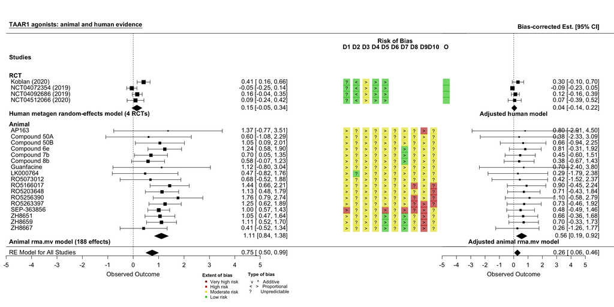

```r
rob_direction(
  taar1_plot_all,
  grouping_levels = c("Animal", "RCT"),
  title = "TAAR1 agonists: animal and human evidence",
  atransf = identity,
  external_subgroup_summaries = external_original_summaries,
  external_subgroup_summaries_adj = external_adjusted_summaries
)
```

# 8 Appendix: sourced helper code

The analysis above sources local helper files. They are shown here for transparency. These chunks are not re-executed in the appendix because the relevant files were already sourced by the main analysis code.

## 8.1 `Functions/BiasCorrect_robviz.R`

```r
# Original function is from R package robvis https://github.com/mcguinlu/robvis/tree/main
# Modified by Chin Yang Shapland on 19/09/24 to visualize estimates, RoB and corrected estimates

# TODO add argument that prevents subgroup summary estimates - in this case, each subgroup will need to be one row closer to each other
# TODO Finish description of function

#' Bias direction plots
#'
#' @description Used to
#'
#' @param dat Dataframe
#' @param vi Vector containing the sampling variances (normally defined as the column within the dataset, i.e. dat$vi). Note: either vi or sei must be set.
#' @param sei Vector containing the corresponding standard errors (normally defined as the column within the dataset, i.e. dat$sei). Note: either vi or sei must be set.
#' @param title Graph title
#' @param legend_cex Expansion factor for figure legend.
#' @param grouping Variable of the provided dataset by which the resulting plot will be stratified. Often will study design or overall risk-of-bias level.
#' @param grouping_levels Ordering of grouping variable. Note: the levels will be plotted
#'   in order, starting at the bottom of the graph (i.e. the last item in the
#'   vector will be placed at the top of the graph)
#' @param label_subgroup_summary Annotation text for subgroup label
#' @param atransf Transformation applied only when drawing estimates and
#'   confidence intervals. Use identity for SMDs; use exp for log-ratio measures.
#' @param external_subgroup_summaries Optional data frame with externally fitted
#'   original subgroup summaries. Expected columns: type, yi, ci.lb, ci.ub, label.
#' @param external_subgroup_summaries_adj Optional data frame with externally
#'   fitted bias-adjusted subgroup summaries. Same expected columns.
#' @param ... Other arguments to pass to metafor::forest
#'
#' @keywords internal

rob_direction <-
  function(dat,
           sei = NULL,
           title = NULL,
           legend_cex = 0.9,
           grouping = "type",
           grouping_levels = c("MR","NRSI","Obs","RCT"),
           label_subgroup_summary = "RE Model for Subgroup",
           atransf = identity,
           external_subgroup_summaries = NULL,
           external_subgroup_summaries_adj = NULL,
           ...) {

    ### calculate log risk ratios and corresponding sampling variances (and use
    ### the 'slab' argument to store study labels as part of the data frame)

    if (("study" %in% colnames(dat)) == FALSE) {
      dat$study <- paste("Study", 1:nrow(dat))
    }

    rob_levels = c("Low","Moderate","High","Critical")

    dat <- dat %>%
      dplyr::mutate(type = factor(type, levels = grouping_levels)) %>%
      dplyr::mutate(overall = factor(overall, levels = rob_levels)) %>%
      dplyr::arrange(type, overall, dplyr::desc(study))

    #dat[is.na(dat)] <- "None"


    # Use this to define the gaps between different groups
    # Will be important when adding argument to prevent subgroup analyses
    offset_n <- 4

    dat_rob_vec <- dat %>%
      dplyr::mutate(row_n = 1:dplyr::n()) %>%
      dplyr::group_by(type) %>%
      dplyr::summarise(n=dplyr::n(),max = max(row_n), min = min(row_n)) %>%
      dplyr::mutate(offset = seq(2,length(unique(.$type))*offset_n,by=offset_n)) %>%
      dplyr::mutate(min = min+offset, max =max+offset, heading = max+1, stats = min-1.25) %>%
      dplyr::mutate(min = ifelse(n==1,min-1,min),
                    max = ifelse(n==1,max-1,max),
                    heading = ifelse(n==1,heading-1,heading))

    if (length(unique(dat$type))==1) {
      dat_rob_vec <- dat_rob_vec %>%
        dplyr::mutate(dplyr::across(c(min, max, heading),~.-1))
    }

    rows <- c()

    for (i in 1:nrow(dat_rob_vec)) {

      rows <-c(rows, dat_rob_vec$min[i]:dat_rob_vec$max[i])

    }

    arg <- list(...)

    # Use a symmetric SMD scale around the line of no effect. This keeps the
    # original and bias-corrected panels comparable and ensures 0 is printed on
    # the bottom axis. The caller can override this with x_min/x_max/at.
    data_ci_min <- min(
      dat$yi - 1.96 * sqrt(dat$vi),
      dat$yi_adj - 1.96 * sqrt(dat$vi_adj),
      na.rm = TRUE
    )
    data_ci_max <- max(
      dat$yi + 1.96 * sqrt(dat$vi),
      dat$yi_adj + 1.96 * sqrt(dat$vi_adj),
      na.rm = TRUE
    )
    if (!is.null(external_subgroup_summaries)) {
      data_ci_min <- min(data_ci_min, external_subgroup_summaries$ci.lb, na.rm = TRUE)
      data_ci_max <- max(data_ci_max, external_subgroup_summaries$ci.ub, na.rm = TRUE)
    }
    if (!is.null(external_subgroup_summaries_adj)) {
      data_ci_min <- min(data_ci_min, external_subgroup_summaries_adj$ci.lb, na.rm = TRUE)
      data_ci_max <- max(data_ci_max, external_subgroup_summaries_adj$ci.ub, na.rm = TRUE)
    }
    symmetric_limit <- ceiling(max(abs(c(data_ci_min, data_ci_max)), na.rm = TRUE))

    if (is.null(arg$x_min)) {
      x_min = -symmetric_limit
    } else {
      x_min <- arg$x_min
    }

    if (is.null(arg$x_max)) {
      x_max = symmetric_limit
    } else {
      x_max <- arg$x_max
    }

    forest_alim <- c(x_min, x_max)

    if (is.null(arg$at)) {
      axis_at <- seq(x_min, x_max, by = 1)
      if (!0 %in% axis_at) {
        axis_at <- sort(unique(c(axis_at, 0)))
      }
    } else {
      axis_at <- arg$at
    }

    # Separate the forest/CIs, printed estimate text, and risk-of-bias columns.
    # Without an explicit plotting limit (`alim` below), long CIs and subgroup
    # polygons can extend into the risk-of-bias grid because the x-axis also
    # includes the ROB columns.
    effect_text_x <- x_max + 1.2
    textpos <- c(x_min, effect_text_x)
    # Reserve vertical headroom above the "Studies" header. The plot title and
    # risk-of-bias header otherwise sit on the PDF device boundary and can be
    # clipped.
    y_max <- max(rows)+10
    title_y <- y_max - 0.8
    rob_header_y <- y_max - 3.2
    domain_header_y <- y_max - 4.2
    forest_header_y <- y_max - 6

    #-#-#-#-#-#-#-#-#-#-#-#-#-#-#-#-#-#-#-#-#-#-#-#-#-#-#-#-#-#-#-#-#-#-#-#-#-#-#-#-
    # Deal with adding rob data
    dat_adj <- dat %>%
      dplyr::mutate(dplyr::across(-c(result_id,study,type, yi_adj, vi_adj), clean_data))
```

```r
    dat <- dat %>%
      dplyr::mutate(dplyr::across(-c(result_id,study,type,yi,vi), clean_data))

    # Combine direction and type for each plotted domain. The package version
    # only loops over D1-D7; TAAR1 animal studies contain D1-D10.
    for (j in paste0("d",1:10)) {
      for (i in 1:nrow(dat)) {
        dat[i,paste0(j,"d")] <- paste0(dat[i,paste0(j,"d")],dat[i,paste0(j,"t")])
      }
    }

    # Put the ten domain columns to the right of the printed estimate text.
    # The PDF output is widened in taar1-agonists.R, so this can use real
    # horizontal space rather than squeezing the risk-of-bias grid into the CIs.
    x_pos <- seq(effect_text_x + 2.2, by = 0.38, length.out = 10)

    x_overall_pos <- max(x_pos) + .5

    # Convenience vector, specifying x-axis positions for all risk of bias columns
    header_row <- c(x_pos, x_overall_pos)

    legend_pos <- x_max+(max(header_row)-min(header_row))/2

    # New right-hand x-axis limit
    new_x_lim <- x_overall_pos + .8

    # Setting colours (changed)
    rob_colours <- c()
    rob_colours$na_colour <- "#cccccc"
    rob_colours$low_colour <- "#02C100"
    rob_colours$concerns_colour <- "#E2DF07"
    rob_colours$high_colour <- "#BF0000"
    rob_colours$critical_colour <- "#820000"
    rob_colours$ni_colour <- "#4EA1F7"

    judgements<-c("Very high risk",  #changed
                  "High risk",
                  "Moderate risk",
                  "Low risk")
    cols <- c(
      c = rob_colours$critical_colour, #changed
      h = rob_colours$high_colour,
      m = rob_colours$concerns_colour,
      l = rob_colours$low_colour,
      n = rob_colours$ni_colour,
      x = "transparent"
    )

    # Direction/type icons drawn inside each ROB square.
    # clean_data() reduces absolute direction and bias type to one letter each.
    # In the current triangulate output the direction keys are usually:
    # - a = away from null
    # - t = towards null
    # - u = unpredictable
    # Older package internals also used l/r for left/right absolute direction,
    # so those keys are retained as fallbacks.
    #
    # Proportional bias changes the estimate multiplicatively, so it is shown
    # with horizontal icons. Additive bias shifts the estimate, so it is shown
    # with vertical icons.
    syms <- c(ua = "?",
              up = "?",
              aa = "^",
              ta = "v",
              ap = ">",
              tp = "<",
              lp = "<",
              rp = ">",
              la = "v",
              ra = "^",
              l = "v",
              r = "^",
              xx = "",
              x = "")

    shapes <- c(c = 15,
                v = 15,
                h = 15,
                m = 15,
                l = 15,
                n = 15,
                x = 15)


    rob_psize = 3
    tsize <- rob_psize * 0.3

    # Use plain ASCII model labels so non-interactive PDF devices do not need
    # CID fonts for plotmath symbols such as tau.
    mlab_text <- function(text, res) {
      paste0(
        text,
        " (p ",
        .pval(res$pval, digits = 2, showeq = TRUE, sep = " "),
        "; I2 = ",
        formatC(res$I2, digits = 1, format = "f"),
        "%, tau2 = ",
        formatC(res$tau2, digits = 2, format = "f"),
        ")"
      )
    }

    external_label <- function(row, fallback) {
      if ("label" %in% names(row) && !is.na(row$label) && nzchar(row$label)) {
        return(row$label)
      }
      fallback
    }

    par(cex=0.9, mai=c(1.5,0.1,0.8,0.1))

    #-#-#-#-#-#-#-#-#-#-#-#-#-#-#-#-#-#-#-#-#-#-#-#-#-#-#-#-#-#-#-#-#-#-#-#-#-#-#-#-
    # Make forest plot

    res_all <- rma(yi, vi, data=dat)

    par(fig=c(0.01,0.76,0,1))
    ### set up forest plot (with 2x2 table counts added; the 'rows' argument is
    ### used to specify in which rows the outcomes will be plotted)
    metafor::forest(res_all,
                    #x = dat$yi,
                    #vi = dat$vi,
                    #sei = sei,
                    xlim=c(x_min, new_x_lim),
                    alim=forest_alim,
                    at=axis_at,
                    atransf=atransf,
                    slab = paste0(" ", dat$study),
                    cex=1.2,
                    ylim=c(-1.5, y_max),
                    rows=rows,
                    textpos = textpos,
                    mlab = "RE Model for All Studies",
                    header=FALSE,
                    ...
    )

    ### set font expansion factor (as in forest() above) and use a bold font
    op <- graphics::par(font=2)

    ### switch to bold italic font
    graphics::par(font=2)

    ### add text for the subgroups
    graphics::text(x_min, -2, pos=4, mlab_text(" ", res_all), cex = 1.2)
    graphics::text(x_min, forest_header_y, pos=4, "Studies", cex = 1.2)

    for (i in 1:nrow(dat_rob_vec)) {

      graphics::text(x_min, dat_rob_vec$heading[i], pos=4, dat_rob_vec$type[i], cex = 1.2)
    }

    ### set par back to the original settings
    graphics::par(op)

    #-#-#-#-#-#-#-#-#-#-#-#-#-#-#-#-#-#-#-#-#-#-#-#-#-#-#-#-#-#-#-#-#-#-#-#-#-#-#-#-
    # Add risk of bias data

    headers <- c("D1", "D2", "D3", "D4", "D5", "D6", "D7", "D8", "D9", "D10", "O")

    graphics::par(font = 2)
    # Need to add handling of top here
    graphics::text(mean(header_row), rob_header_y, labels = "Risk of Bias", cex=1.2)
    graphics::text(header_row, domain_header_y, labels = headers, cex=1.2)
    graphics::par(op)

    # Plot domain points
    for (j in 1:length(x_pos)) {
      graphics::points(
        x = rep(x_pos[j], length(rows)),
        y = rows,
        pch = shapes[dat[[paste0("d", j,"j")]]],
        col = scales::alpha(cols[dat[[paste0("d", j,"j")]]],0.6),
        cex = rob_psize
      )
      graphics::text(x_pos[j], rows, syms[dat[[paste0("d", j,"d")]]], cex = tsize)
    }

    graphics::points(
      rep(x_overall_pos, length(rows)),
      rows,
      pch = 15,
      col = scales::alpha(cols[dat[["overall"]]],0.6),
      cex = rob_psize
    )
    # graphics::text(x_overall_pos, rows, syms[dat[["overall"]]], cex = tsize)
    graphics::par(op)
```

```r
    # #-#-#-#-#-#-#-#-#-#-#-#-#-#-#-#-#-#-#-#-#-#-#-#-#-#-#-#-#-#-#-#-#-#-#-#-#-#-#-#-
    #


    #-#-#-#-#-#-#-#-#-#-#-#-#-#-#-#-#-#-#-#-#-#-#-#-#-#-#-#-#-#-#-#-#-#-#-#-#-#-#-#-
    # Add sub-group, summary polygons & text

    rma_flexi <- function(x) {
      metafor::rma(
        yi,
        vi,
        subset = (type == x),
        data = dat,
        #method = "DL"  ### CHANGE to have "REML" the default rma
      )
    }


    res <- purrr::map(dat_rob_vec$type, rma_flexi)

    if (length(unique(dat$type))>1) {

      ### add summary polygons for the three subgroups
      for (i in 1:nrow(dat_rob_vec)) {
        type_i <- as.character(dat_rob_vec$type[i])
        ext_i <- NULL
        if (!is.null(external_subgroup_summaries)) {
          ext_i <- external_subgroup_summaries[external_subgroup_summaries$type == type_i, , drop = FALSE]
          if (nrow(ext_i) == 0) {
            ext_i <- NULL
          } else {
            ext_i <- ext_i[1, , drop = FALSE]
          }
        }

        if (!is.null(ext_i)) {
          metafor::addpoly(
            x = ext_i$yi,
            ci.lb = ext_i$ci.lb,
            ci.ub = ext_i$ci.ub,
            rows = dat_rob_vec$stats[i],
            cex = 1.2,
            textpos = textpos,
            atransf = atransf,
            annotate = FALSE,
            # The external model label is drawn explicitly below the polygon.
            # Keep addpoly()'s mlab empty so the same label is not printed twice.
            mlab = ""
          )

          graphics::par(font = 2)
          graphics::text(x_min, dat_rob_vec$stats[i]-1, pos=4, external_label(ext_i, "External subgroup model"), cex = 1.2)
          graphics::par(op)

          annotate_poly(ext_i$yi,
                        ext_i$ci.lb,
                        ext_i$ci.ub,
                        atransf = atransf,
                        textpos = textpos,
                        rows = dat_rob_vec$stats[[i]])
          next
        }

        if (length(res[[i]]$slab) == 1) {
          next
        }

        metafor::addpoly(
          res[[i]],
          #fonts = 1,
          row = dat_rob_vec$stats[i],
          cex = 1.2,
          textpos=textpos,
          atransf = atransf,
          annotate = F,
          mlab = label_subgroup_summary
        )

        graphics::par(font = 2)
        # Need to add handling of top here
        graphics::text(x_min, dat_rob_vec$stats[i]-1, pos=4, mlab_text(" ", res[[i]]), cex = 1.2)
        graphics::par(op)

        annotate_poly(res[[i]]$b,
                      res[[i]]$ci.lb,
                      res[[i]]$ci.ub,
                      atransf = atransf,
                      textpos = textpos,
                      rows = dat_rob_vec$stats[[i]])

      }
    }

    #-#-#-#-#-#-#-#-#-#-#-#-#-#-#-#-#-#-#-#-#-#-#-#-#-#-#-#-#-#-#-#-#-#-#-#-#-#-#-#-

    if(!is.null(title)){
      graphics::par(font = 2)
      graphics::text(x_min, title_y, pos=4, bquote(bold(underline(.(title)))), cex = 1.2)
      graphics::par(op)
    }

    #-#-#-#-#-#-#-#-#-#-#-#-#-#-#-#-#-#-#-#-#-#-#-#-#-#-#-#-#-#-#-#-#-#-#-#-#-#-#-#-

    #-#-#-#-#-#-#-#-#-#-#-#-#-#-#-#-#-#-#-#-#-#-#-#-#-#-#-#-#-#-#-#-#-#-#-#-#-#-#-#-

    graphics::legend(
      legend_pos-3.5,                         #changed
      -4,                                   #changed
      c(judgements),
      pch = c(15,15,15,15,16,50),           #changed
      xjust = 0.5,
      col = c(cols[1:4],"white","white"),   #changed
      xpd = TRUE,
      title = parse(text = "bold(\"Extent of bias\")"),
      title.adj = 0.05,
      cex = legend_cex,
      pt.cex = legend_cex-.1,
      y.intersp = 0.9,                     #changed
      box.col = "white",
    )

    graphics::legend(
      legend_pos-1.5,                    #changed
      -4,                                #changed
      c("v   ^   Additive","<   >   Proportional", "?       Unpredictable"),
      xjust = 0.5,
      xpd = TRUE,
      adj = 0.15,
      title = parse(text = "bold(\"Type of bias\")"),
      title.adj = 0.05,
      cex = legend_cex,
      pt.cex = legend_cex,
      y.intersp = 0.9,
      box.col = "white"
    )
    #
    #-#-#-#-#-#-#-#-#-#-#-#-#-#-#-#-#-#-#-#-#-#-#-#-#-#-#-#-#-#-#-#-#-#-#-#-#-#-#-#-
    # Make forest plot with adjusted estimates

    par(fig=c(0.72,1,0,1), new=TRUE)

    res_adj <- rma(yi_adj, vi_adj, data=dat_adj)

    ### set up forest plot (with 2x2 table counts added; the 'rows' argument is
    ### used to specify in which rows the outcomes will be plotted)
    metafor::forest(res_adj,
                    #x = dat$yi,
                    #vi = dat$vi,
                    #sei = sei,
                    xlim=c(x_min, x_max + 2),
                    alim=forest_alim,
                    at=axis_at,
                    atransf=atransf,
                    slab = NA,
                    cex=1.2,
                    ylim=c(-1.5, y_max),
                    rows=rows,
                    textpos = c(x_min, x_max + 1.2),
                    mlab = NA,
                    header=c(" ", "Bias-corrected Est. [95% CI]"),
                    ...
    )

    ### set font expansion factor (as in forest() above) and use a bold font
    op <- graphics::par(font=2)

    graphics::text(x_min-.4, -2, pos=4, mlab_text(" ", res_adj), cex = 1.2)

    ### set par back to the original settings
    graphics::par(op)


    #-#-#-#-#-#-#-#-#-#-#-#-#-#-#-#-#-#-#-#-#-#-#-#-#-#-#-#-#-#-#-#-#-#-#-#-#-#-#-#-
    # Add sub-group, summary polygons & text

    rma_flexi_adj <- function(x) {
      metafor::rma(
        yi_adj,
        vi_adj,
        subset = (type == x),
        data = dat_adj,
        #method = "DL"  ### CHANGE to have "REML" the default rma
      )
    }


    res_adj <- purrr::map(dat_rob_vec$type,  rma_flexi_adj)

    if (length(unique(dat$type))>1) {

      ### add summary polygons for the three subgroups
      for (i in 1:nrow(dat_rob_vec)) {
        type_i <- as.character(dat_rob_vec$type[i])
        ext_i <- NULL
        if (!is.null(external_subgroup_summaries_adj)) {
          ext_i <- external_subgroup_summaries_adj[external_subgroup_summaries_adj$type == type_i, , drop = FALSE]
          if (nrow(ext_i) == 0) {
            ext_i <- NULL
          } else {
            ext_i <- ext_i[1, , drop = FALSE]
          }
        }
```

```r
        if (!is.null(ext_i)) {
          metafor::addpoly(
            x = ext_i$yi,
            ci.lb = ext_i$ci.lb,
            ci.ub = ext_i$ci.ub,
            rows = dat_rob_vec$stats[i],
            cex = 1.2,
            textpos = textpos,
            atransf = atransf,
            annotate = FALSE,
            mlab = ""
          )

          graphics::par(font = 2)
          # Center the adjusted model label on the 0 SMD reference line so it
          # stays inside the bias-corrected forest panel.
          graphics::text(0, dat_rob_vec$stats[i]-1, external_label(ext_i, "External adjusted subgroup model"), cex = 1.2)
          graphics::par(op)

          annotate_poly(ext_i$yi,
                        ext_i$ci.lb,
                        ext_i$ci.ub,
                        atransf = atransf,
                        textpos = c(x_min, x_max + 1.2),
                        rows = dat_rob_vec$stats[[i]])
          next
        }

        if (length(res_adj[[i]]$slab) == 1) {
          next
        }

        metafor::addpoly(
          res_adj[[i]],
          row = dat_rob_vec$stats[i],
          cex = 1.2,
          textpos=textpos,
          atransf = atransf,
          annotate = F,
          mlab = ""
        )

        graphics::par(font = 2)
        # Need to add handling of top here
        graphics::text(x_min-.4, dat_rob_vec$stats[i]-1, pos=4, mlab_text(" ", res_adj[[i]]), cex = 1.2)
        graphics::par(op)

        annotate_poly(res_adj[[i]]$b,
                      res_adj[[i]]$ci.lb,
                      res_adj[[i]]$ci.ub,
                      atransf = atransf,
                      textpos = c(x_min, x_max + 1.2),
                      rows = dat_rob_vec$stats[[i]])

      }
    }
}
```

## 8.2 `Functions/helpers.R`

```r
# Original function is from R package robvis https://github.com/mcguinlu/robvis/tree/main

get_judgements <- function(tool){
  # TODO Need to double check the options for each tool

  if (tool == "ROB2") {
    values = c("High", "Some concerns", "Low", "No information")
  }

  if (tool == "ROB2-Cluster") {
    values = c("High",
               "Some concerns",
               "Low",
               "No information",
               "Not applicable")
  }

  if (tool == "ROBINS-I") {
    values = c("Critical",
               "Serious",
               "Moderate",
               "Low",
               "No information")
  }

  if (tool == "ROBINS-E") {
    values = c("Very high",
               "High",
               "Some concerns",
               "Low",
               "No information")
  }

  if (tool == "QUADAS-2") {
    values = c("High", "Some concerns", "Low", "No information")

  }

  if (tool == "Generic") {
    values = c(
      "High",
      "Unclear",
      "Some concerns",
      "Moderate",
      "Low",
      "No information",
      "Not applicable"
    )
  }

  return(values)
}

check_cols <- function(data,
                       max_domain_column,
                       overall,
                       type = "tf",
                       weight = FALSE){

  expected_col <- max_domain_column + 1

  if (!overall & !weight) {
    expected_col <- expected_col - 2
    domain_text = paste0(expected_col,
                         ": a \"Study\" column and ",
                         max_domain_column - 2,
                         " \"Domain\" columns.")
    var_ind <- "neither"

  }

  if (!overall & weight) {
    expected_col <- expected_col - 1
    domain_text = paste0(
      expected_col,
      ": a \"Study\" column, ",
      max_domain_column - 1,
      " \"Domain\" columns, and \"Weight\" column."
    )
    var_ind <- "weight"
  }

  if (overall & !weight) {
    expected_col <- expected_col - 1
    domain_text = paste0(
      expected_col,
      ": a \"Study\" column, ",
      max_domain_column - 1,
      " \"Domain\" columns, and an \"Overall\" column."
    )
    var_ind <- "overall"
  }

  if (overall & weight) {
    expected_col <- expected_col
    domain_text = paste0(
      expected_col,
      ": a \"Study\" column, ",
      max_domain_column - 2,
      " \"Domain\" columns, an \"Overall\" column and a \"Weight\" column."
    )
    var_ind <- "both"
  }

  if (type == "summ") {
    weighted_text <- paste(" and weighted =", weight)
  } else {
    weighted_text <- ""
  }

  if (ncol(data) == expected_col) {
    if ((var_ind %in% c("both", "weight")) &&
        unique(grepl("^[-]{0,1}[0-9]{0,}.{0,1}[0-9]{1,}$",
                     data[[ncol(data)]])) == FALSE) {
      stop(
        "Error. The final column does not seem to contain numeric values ",
        "(expected for weighted = TRUE)."
      )
    }} else {
      if (ncol(data) != expected_col) {
        stop(
          "The number of columns in your data (",
          ncol(data),
          ") does not match the number expected for this",
          " tool when using overall = ", overall, weighted_text,
          ". The expected number of columns is ",
          domain_text
        )}
    }
}


tidy_data <- function(data,
                      max_domain_column,
                      domain_names,
                      overall,
                      levels) {

  # Deal with legacy versions of the example datasets
  # if (ncol(data) == max_domain_column + 1) {
  #   if (overall == FALSE) {
  #     data <- data[,c(1:(ncol(data)-2))]
  #   } else {
  #     data <- data[,-ncol(data)]
  #   }
  # }

  check_cols(data = data,
             max_domain_column = max_domain_column,
             overall = overall,
             weight = FALSE)

  if (!overall) {
    max_domain_column <- max_domain_column - 1
    domain_names <- domain_names[1:max_domain_column]
  }

  data.tmp <-
    cbind(data[, 1], data.frame(lapply(data[, 2:max_domain_column], clean_data),
                                stringsAsFactors = F))

  names(data.tmp) <- domain_names

  rob.tidy <- suppressWarnings(tidyr::gather(data.tmp,
                                             domain, judgement,-Study))


  rob.tidy$Study <-
    factor(rob.tidy$Study, levels = unique(data.tmp$Study))

  rob.tidy$judgement <- as.factor(rob.tidy$judgement)

  rob.tidy$judgement <-
    factor(rob.tidy$judgement, levels = levels)

  rob.tidy
}

tidy_data_summ <- function(data,
                           max_domain_column,
                           overall,
                           weighted,
                           domain_names,
                           levels) {

  # Deal with legacy versions of the example datasets
  if (ncol(data) == max_domain_column + 1) {
    if (overall == FALSE) {
      data <- data[,c(1:max_domain_column-1,max_domain_column + 1)]
    }
    if (weighted == FALSE) {
      data <- data[,-ncol(data)]
    }
  }

  # Check columns are as expected, given the options
  check_cols(
    data = data,
    max_domain_column = max_domain_column,
    overall = overall,
    type = "summ",
    weight = weighted
  )

  if (overall ==  FALSE) {
    max_domain_column <- max_domain_column - 1
    domain_names <- domain_names[c(1:max_domain_column, length(domain_names))]
  }

  if (weighted == FALSE) {
    data[, max_domain_column + 1] <- rep(1, length(nrow(data)))
  }

  data.tmp <-
    cbind(data[,1],data.frame(lapply(data[, 2:max_domain_column], clean_data),
                              data[, ncol(data)],
                              stringsAsFactors = F))

  names(data.tmp) <- domain_names

  rob.tidy <- suppressWarnings(tidyr::gather(
    data.tmp[-1],
    domain, judgement, -Weights
  ))

  rob.tidy$domain <- as.factor(rob.tidy$domain)

  rob.tidy$domain <-
    factor(rob.tidy$domain,
           levels = rev(domain_names))

  rob.tidy$judgement <-
    factor(rob.tidy$judgement, levels = levels)

  rob.tidy
}


rob_summ_theme <- function(overall = TRUE, max_domain_column){
  standard <- list(
    ggplot2::geom_bar(
      mapping = ggplot2::aes(
        x = domain,
        fill = judgement,
        weight = Weights
      ),
      width = 0.7,
      position = "fill",
      color = "black"
    ),
    ggplot2::coord_flip(ylim = c(
      0,
      1
    )),
    ggplot2::guides(fill = ggplot2::guide_legend(reverse = T)),
    ggplot2::scale_y_continuous(labels = scales::percent),
    ggplot2::theme(
      axis.title.x = ggplot2::element_blank(),
      axis.title.y = ggplot2::element_blank(),
      axis.ticks.y = ggplot2::element_blank(),
      axis.line.x = ggplot2::element_line(
        colour = "black",
        size = 0.5,
        linetype = "solid"
      ),
      legend.position = "bottom",
      panel.grid.major = ggplot2::element_blank(),
      panel.grid.minor = ggplot2::element_blank(),
      panel.background = ggplot2::element_blank(),
      legend.background = ggplot2::element_rect(
        linetype = "solid",
        colour = "black"
      ),
      legend.title = ggplot2::element_blank(),
      legend.key.size = ggplot2::unit(0.75, "lines"),
      legend.text = ggplot2::element_text(size = 6)
    ),
    bold_overall = ggplot2::theme(axis.text.y = ggplot2::element_text(
      size = 10,
      color = "black"
    ))
  )
```

```r
  if (overall) {
    standard[["bold_overall"]] <-
      ggplot2::theme(axis.text.y = suppressWarnings(ggplot2::element_text(size = 10,
                                                                          color = "black",
                                                                          face = c("bold", rep("plain",max_domain_column)))))
  }

  return(standard)
}


rob_tf_theme <-function(rob.tidy,
                        domain_names,
                        psize,
                        ssize,
                        adjust_caption,
                        overall,
                        judgement_title = "Judgement",
                        overall_name = "Overall",
                        x_title = "Risk of bias domains",
                        y_title = "Study"){
  standard <- list(
    ggplot2::facet_grid(Study ~
                          factor(domain, levels = domain_names),
                        switch = "y",
                        space = "free"),
    ggplot2::geom_point(size = 6),
    ggplot2::geom_point(size = 4,
                        colour = "black",
                        ggplot2::aes(shape = judgement)),
    ggplot2::geom_rect(
      data = rob.tidy[which(rob.tidy$domain !=
                              overall_name),],
      fill = "#ffffff",
      xmin = -Inf,
      xmax = Inf,
      ymin = -Inf,
      ymax = Inf,
      show.legend = FALSE
    ),
    overall_name = ggplot2::geom_rect(
      data = rob.tidy[which(rob.tidy$domain ==
                              overall_name),],
      fill = "#d3d3d3",
      xmin = -Inf,
      xmax = Inf,
      ymin = -Inf,
      ymax = Inf,
      show.legend = FALSE
    ),
    ggplot2::geom_point(size = psize, show.legend = FALSE),
    ggplot2::geom_point(
      data = rob.tidy[which(rob.tidy$judgement !=
                              "x"),],
      shape = 1,
      colour = "black",
      size = psize,
      show.legend = FALSE
    ),
    ggplot2::geom_point(
      size = ssize,
      colour = "black",
      ggplot2::aes(shape = judgement),
      show.legend = FALSE
    ),
    ggplot2::scale_x_discrete(position = "top", name = x_title),
    ggplot2::scale_y_continuous(
      limits = c(1, 1),
      labels = NULL,
      breaks = NULL,
      name = y_title,
      position = "left"
    ),
    ggplot2::scale_size(range = c(5,20)),
    ggplot2::theme_bw(),
    ggplot2::theme(
      panel.border = ggplot2::element_rect(colour = "grey"),
      panel.spacing = ggplot2::unit(0, "line"), legend.position = "bottom",
      legend.justification = "right", legend.direction = "vertical",
      legend.margin = ggplot2::margin(
        t = -0.2, r = 0,
        b = adjust_caption, l = -10, unit = "cm"
      ),
      strip.text.x = ggplot2::element_text(size = 10),
      strip.text.y.left = ggplot2::element_text(
        angle = 0,
        size = 10
      ), legend.text = ggplot2::element_text(size = 9),
      legend.title = ggplot2::element_text(size = 9),
      strip.background = ggplot2::element_rect(fill = "#a9a9a9"),
      plot.caption = ggplot2::element_text(
        size = 10,
        hjust = 0, vjust = 1
      )
    ),
    ggplot2::guides(shape = ggplot2::guide_legend(
      override.aes = list(fill = NA))),
    ggplot2::labs(shape = judgement_title, colour = judgement_title)

  )

  # Remove element that draws dark box for "Overall" column
  if (!overall) {
    standard[["overall_name"]] <- ggplot2::geom_blank()
  }

  return(standard)

}


get_caption_adjustment <- function(data){
  -0.7 + length(unique(data$judgement)) * -0.6
}

check_data <- function(data){

  header <- stringr::str_to_lower(data[1,])

  if (any(c("study","overall", "weight") %in% header)) {
    stop(paste("It looks like the first row of your dataset contains column",
               "headings (e.g. \"Study\", \"Overall\"). Did you set ",
               "\"header = TRUE\" when reading in your data?")
    )
  }

}

# Check colours
check_colour <- function(tool, colour) {
  if(!(colour[1] %in% c("cochrane","colourblind"))){
    if (tool == "ROB2" || tool == "ROB2-Cluster" || tool == "QUADAS-2") {
      if(length(colour)!=4){
        stop(paste("Wrong number of colours specified.",
                   "This template expects 4 colours."))
      }

    } else{
      if(length(colour)!=5){
        stop(paste("Wrong number of colours specified.",
                   "This template expects 5 colours."))
      }
    }
  }
}

# Define colours used
get_colour <- function(tool, colour) {
  rob_colours <- c()

  rob_colours$na_colour <- "#cccccc"

  if (tool == "ROB2" || tool == "ROB2-Cluster" || tool == "QUADAS-2") {
    if (length(colour) > 1) {
      rob_colours$low_colour <- colour[c(1)]
      rob_colours$concerns_colour <- colour[c(2)]
      rob_colours$high_colour <- colour[c(3)]
      rob_colours$ni_colour <- colour[c(4)]
    } else {
      if (colour == "colourblind") {
        rob_colours$low_colour <- "#fed98e"
        rob_colours$concerns_colour <- "#fe9929"
        rob_colours$high_colour <- "#d95f0e"
        rob_colours$ni_colour <- "#ffffff"
      }
      if (colour == "cochrane") {
        rob_colours$low_colour <- "#02C100"
        rob_colours$concerns_colour <- "#E2DF07"
        rob_colours$high_colour <- "#BF0000"
        rob_colours$ni_colour <- "#4EA1F7"
      }
    }
  } else {
    if (length(colour) > 1) {
      rob_colours$low_colour <- colour[c(1)]
      rob_colours$concerns_colour <- colour[c(2)]
      rob_colours$high_colour <- colour[c(3)]
      rob_colours$critical_colour <- colour[c(4)]
      rob_colours$ni_colour <- colour[c(5)]
    } else {
      if (colour == "colourblind") {
        rob_colours$low_colour <- "#fed98e"
        rob_colours$concerns_colour <- "#fe9929"
        rob_colours$high_colour <- "#d95f0e"
        rob_colours$critical_colour <- "#993404"
        rob_colours$ni_colour <- "#ffffff"
      }
      if (colour == "cochrane") {
        rob_colours$low_colour <- "#02C100"
        rob_colours$concerns_colour <- "#E2DF07"
        rob_colours$high_colour <- "#BF0000"
        rob_colours$critical_colour <- "#820000"
        rob_colours$ni_colour <- "#4EA1F7"
      }
    }
  }
```

```r
  return(rob_colours)
}

# Make sure specified tool is allowed
check_tool <- function(tool, forest = FALSE) {

  if (forest) {
    tools <- c(suppressMessages(rob_tools(forest = TRUE)))
    message_content <- "rob_tools(forest = TRUE)"
  }else {
    tools <- c(suppressMessages(rob_tools()), "ROB1")
    message_content <- "rob_tools()"
  }

  if ((tool %in% tools) == FALSE) {
    stop(
      paste(
        "\nTool name \"",
        tool,
        "\" not recognised \nAcceptable tools" ,
        "names can be found by running",
        message_content
      )
    )
  }
}

# Give depreciated warning if "ROB1" specified
rob1_warning <- function(tool) {
  if (tool == "ROB1") {
    message(
      paste0(
        "Note: In future versions of robvis, the 'tool = \"ROB1\"' ",
        "argument will be depreciated.\n",
        "Please use 'tool = \"Generic\"' instead."
      )
    )
  }
}

# Get recommended height of figure, used by rob_save
get_height <- function(data, tool, psize, type = "tf") {
  if (type == "tf") {
    tool_adj <- ifelse(tool %in% c("ROBINS-I", "Generic"), 2.5, 2)
    nrows <- nrow(data)
    height <- tool_adj + nrows * .4 / (10 / psize)
  } else {
    height <- 2.41
  }
  return(height)
}

# Get recommended width of figure, used by rob_save
get_width <- function(data, psize, type = "tf") {
  if (type == "tf") {
    # Account for long study names
    nchar_study <- max(nchar(as.character(data$Study)))
    nchar_domain <- max(nchar(as.character(colnames(data)))) + 3
    width_adj <- ifelse(nchar_study > 8, 6 + nchar_study * 0.05, 6)
    width <-
      ifelse(nchar_domain > 42,
             width_adj + (nchar_domain - 42) * 0.05,
             width_adj
      )
  } else {
    width <- 8
  }
  return(width)
}

# Allow for US spelling of "colourblind"
weird_spelling <- function(colour) {
  colour <- ifelse(colour == "colorblind", "colourblind", colour)
  return(colour)
}

# Acceptable file extensions for saving

get_extension <- function(file){
  ex <- strsplit(basename(file), split="\\.")[[1]]
  return(ex[-1])
}

check_extension <- function(file){
  if (!(get_extension(file) %in% c("png","jpeg","tiff","eps"))) {
    stop(paste0("Saving to this file type is not supported by robvis. ",
                "Acceptable file types are \".png\", \".jpeg\", ",
                " \".tiff\", and \".eps\". "))
  }
}

clean_data <- function(col) {
  col <- gsub("\\b(\\pL)\\pL{1,}|.", "\\U\\1", col, perl = TRUE)
  col <- trimws(tolower(col))
  col <- ifelse(col %in% c("na", "n") | is.na(col), "x", col)
  col <- substr(col, 0, 1)
  return(col)
}

# Used in testing ==============================================================
save_png <- function(code, width = 1400, height = 800) {
  path <- tempfile(fileext = ".png")
  grDevices::png(path, width = width, height = height)
  on.exit(grDevices::dev.off())
  code

  return(path)
}

get_res <- function(tool){

  dat.bcg <-
    cbind(metadat::dat.bcg, rob_dummy(13, tool, study = FALSE))

  dat <-
    metafor::escalc(
      measure = "RR",
      ai = tpos,
      bi = tneg,
      ci = cpos,
      di = cneg,
      data = dat.bcg,
      slab = paste(author, year, sep = ", ")
    ) %>%
    dplyr::mutate(Study = paste(author, year))

  # Prep bias datasets
  res <- metafor::rma(yi, vi, data = dat, slab = paste(author, year))

  return(res)
}
```

## 8.3 `Functions/helpers-metafor.R`

```r
############################################################################
# The functions contained in this file were written by Wolfgang Viechtbauer as
# part of his {metafor} (https://www.metafor-project.org/doku.php) package.

# As rob_forest() builds on the metafor::forest() function, there were
# some internal {metafor} functions needed to properly render the plot.

############################################################################

.pval <- function(p, digits=4, showeq=FALSE, sep="", add0=FALSE) {

  digits  <- max(digits, 1)
  cutoff  <- paste(c(".", rep(0,digits-1),1), collapse="")
  ncutoff <- as.numeric(cutoff)

  ifelse(is.na(p), paste0(ifelse(showeq, "=", ""), sep, NA),
         ifelse(p >= ncutoff, paste0(ifelse(showeq, "=", ""), sep, formatC(p, digits=digits, format="f")),
                paste0("<", sep, ifelse(add0, "0", ""), cutoff)))

}

mlabfun <- function(text, res) {

  list(bquote(paste(.(text),
                    " (",
                    # " Q = ", .(formatC(res$QE, digits=2, format="f")),
                    # ", df = ", .(res$k - res$p),
                    "p ", .(.pval(res$pval, digits=2, showeq=TRUE, sep=" ")), "; ",
                    I^2, " = ", .(formatC(res$I2, digits=1, format="f")), "%, ",
                    tau^2, " = ", .(formatC(res$tau2, digits=2, format="f")), ")")))

}



annotate_poly <- function(yi, ci.lb, ci.ub, atransf = exp, textpos = 2, width, rows, cex=1.2){

  if (is.function(atransf)) {

    annotext <- cbind(sapply(yi, atransf), sapply(ci.lb, atransf), sapply(ci.ub, atransf))
    ### make sure order of intervals is always increasing

    tmp <- .psort(annotext[,2:3])
    annotext[,2:3] <- tmp

  } else {

    annotext <- cbind(yi, ci.lb, ci.ub)

  }

  annotext <- .fcf(annotext, 2)

  if (missing(width) || is.null(width)) {
    width <- apply(annotext, 2, function(x) max(nchar(x)))
  } else {
    if (length(width) == 1L)
      width <- rep(width, ncol(annotext))
  }

  for (j in seq_len(ncol(annotext))) {
    annotext[,j] <- formatC(annotext[,j], width=width[j])
  }

  annotext <- cbind(annotext[,1], " [", annotext[,2], ", ", annotext[,3], "]")
  annotext <- apply(annotext, 1, paste, collapse="")
  graphics::text(x=textpos, rows, labels=annotext, pos=2, cex=cex)

}


.fcf <- function(x, digits) {

  if (all(is.na(x))) { # since formatC(NA, format="f", digits=2) fails
    x
  } else {
    trimws(formatC(x, format="f", digits=digits))
  }

}

.psort <- function(x,y) {

  if (is.null(x) || length(x) == 0L) ### need to catch this
    return(NULL)

  if (missing(y)) {
    if (is.matrix(x)) {
      xy <- x
    } else {
      xy <- rbind(x) ### in case x is just a vector
    }
  } else {
    xy <- cbind(x,y)
  }

  n <- nrow(xy)

  for (i in seq_len(n)) {
    if (anyNA(xy[i,]))
      next
    xy[i,] <- sort(xy[i,])
  }

  colnames(xy) <- NULL

  return(xy)

}
```

## 8.4 `Functions/animal-helpers.R`

```r
# code chunks come from: https://github.com/galenos-project/LSR3_taar1_A/blob/main/util_u1/util.R
### full code at: https://github.com/galenos-project/LSR3_taar1_A/tree/main


forest_subgroup <- function(modelsumm, moderator, outcome, moderator_text) {
  # this uses GGplot2 to draw a forest plot for the subgroup analyses, and returns the plot

  title <- paste0("Effect of TAAR1 Agonists on ",outcome, " by ", moderator_text)

  model <- modelsumm
  colnames(model) <- c('moderator','k','SMD','se','p','ci_l','ci_u','symbol','size','summary','fontfaace','fontsize','d1','d2')
  model$order <- as.numeric(rownames(model))
  model$estimate_lab = paste0(sprintf('%.2f',model$SMD)," (", sprintf('%.2f',model$ci_l,2),",", sprintf('%.2f',model$ci_u,2),")")
  model <- model %>%
    arrange(order) %>%
    mutate(moderator = factor(model[["moderator"]], levels = unique(model[["moderator"]])))
  lnth <- nrow(model)+1

  axis_min <- min(floor(min(model$ci_l, model$ci_u)),-2)
  axis_max <- max(ceiling(max(model$ci_l, model$ci_u)),1)
  span2 <- 1 + (axis_max - axis_min)
  span1 <- span2 * 0.8
  span3 <- span2 * 0.5
  r1 <- span1
  l2 <- span1 + 1
  r2 <- span1 + span2 + 1
  l3 <- span1 + span2 + 2
  r3 <- span1 + span2 + span3 + 2

  cf <- span2/lnth

  top_margin <- 2

  poly1 <- subset(model, model$moderator == "Overall estimate")
  upp <- 1 + ((poly1$SMD - poly1$ci_l)/(cf *2))
  lop<- 1 - ((poly1$SMD - poly1$ci_l)/(cf *2))
  dfp <- data.frame(x = c(poly1$SMD, poly1$ci_u, poly1$SMD, poly1$ci_l), y = c(lop, 1, upp, 1))

  model <- model %>%
    arrange(order) %>%
    mutate(moderator = factor(moderator, levels = unique(moderator)))
  p_mid <- model %>%
    ggplot(aes(y = fct_rev(moderator))) +
    theme_classic() +
    geom_point(aes(x = SMD), shape = model$symbol, size = model$size) +
    geom_linerange(aes(xmin = ci_l, xmax = ci_u)) +
    labs(x = "SMD Effect size") +
    coord_cartesian(ylim = c(0, lnth + top_margin), xlim = c(axis_min-1, axis_max+1)) +
    geom_vline(xintercept = 0, linetype = "solid") +
    geom_vline(xintercept = poly1$SMD, linetype = "dashed") +
    annotate("text", x = axis_min-1, y = lnth + top_margin - 0.5, label = "TAAR1 Agonist\nworse", hjust = 0) +
    annotate("text", x = axis_max+1, y = lnth + top_margin - 0.5, label = "TAAR1 Agonist\nbetter", hjust = 1) +
    geom_polygon(data = dfp, aes(x = x, y = y), fill = "grey") +
    theme(axis.line.y = element_blank(),
          axis.ticks.y = element_blank(),
          axis.text.y = element_blank(),
          axis.title.y = element_blank())

  p_left <-
    model %>%
    ggplot(aes(y = fct_rev(moderator))) +
    geom_text(aes(x = 0, label = moderator), hjust = 0, size = model$fontsize) +
    geom_text(aes(x = r1, label = k), hjust = 1, size = model$fontsize) +
    annotate("text", x = r1, y = lnth  + top_margin - 0.5, label = "Number of\nexperimental contrasts", hjust=1) +
    theme_void() +
    coord_cartesian(ylim = c(0, lnth + top_margin), xlim = c(0, span1))

  p_right <-
    model %>%
    ggplot() +
    geom_text(aes(x = span3, y = fct_rev(moderator), label = estimate_lab),size = model$fontsize, hjust = 1) +
    coord_cartesian(ylim = c(0, lnth + top_margin), xlim = c(0, span3)) +
    theme_void()

  layout <- c(
    area(t = 0, l = 0, b = 30, r = r1),
    area(t = 1, l = l2, b = 30, r = r2),
    area(t = 0, l = l3, b = 30, r = r3)
  )

  p_left + p_mid + p_right + plot_layout(design = layout) +
    plot_annotation(
      title = title,
      theme = theme(plot.title = element_text(hjust = 0.5, margin = margin(b = 20)),  # Add margin below title
                    plot.margin = margin(t = 40, r = 10, b = 10, l = 10)
      )
    )
}


subgroup_analysis <- function(df, experiment_type, outcome, moderator, rho_value) {
  # this returns a table of effect sizes etc by moderator, for passing to 'forest_subgroup'
  # for plotting

  # Ensure the moderator is a character string for later conversion to symbol
  moderator <- as.character(moderator)

  df2 <- df %>%
    filter(SortLabel == experiment_type) %>%
    filter(outcome_type == outcome) %>%
    filter(!is.na(SMDv)) %>%
    filter(!is.na(!!sym(moderator))) # Filter out NA values in moderator column

  # Convert character to factor if necessary
  if (is.character(df2[[moderator]])) {
    df2[[moderator]] <- factor(df2[[moderator]])}

  # List of factors to consider
  factors_to_consider <- c("Strain", "StudyId", "ExperimentID_I")

  # Create the random effects formula
  random_formula <- create_formula(factors_to_consider, df2)

  if (is.null(random_formula)) {
    cat("Insufficient levels for random effects grouping. Skipping meta-analysis.\n")
    return(NULL)
  }
  # Add a check for the number of levels in the moderator variable
  if (length(levels(df2[[moderator]])) >= 1) {
    #  message("In this iteration of the review, there was insufficient data to perform subgroup analysis for this variable (data for one subgroup only)")
    #  return(NULL)
    #}


    df2 <- df2 %>% mutate(effect_id = row_number()) # add effect_id column

    #calculate variance-covariance matrix of the sampling errors for dependent effect sizes

    VCVM_SMD <- vcalc(vi = SMDv,
                      cluster = StudyId,
                      subgroup= ExperimentID_I,
                      obs=effect_id,
                      data = df2,
                      rho = rho_value)

    # ML model on df2 with subgroup
    subgroup_analysis <- rma.mv(
      yi = SMD,
      V = VCVM_SMD,
      random = random_formula,
      data = df2,
      mods = as.formula(paste("~", moderator, "-1")),
      method = 'REML',
      test = "t",
      dfs = "contain"
    )

    #subgroup_analysis_predict <- predict(subgroup_analysis)

    ## ML model on df2 without subgroup
    overall_estimate_rma <- rma.mv(yi = SMD,
                                   V = VCVM_SMD,
                                   random = random_formula, # nested levels
                                   test = "t", # use t- and F-tests for making inferences
                                   data = df2,
                                   rho = rho_value,
                                   dfs="contain", # improve degree of freedom estimation for t- and F-distributions
                                   control=list(optimizer="nlminb"))

    #overall_estimate_rma_predict <- predict(overall_estimate_rma)


    k_subgroups <- df2 %>%
      group_by(df2[[moderator]]) %>%
      count() %>%
      pull(n)


    subgroup_analysis_plotdata <- data.frame(levels(df2[[moderator]]), k_subgroups, subgroup_analysis$beta, subgroup_analysis$se, subgroup_analysis$pval, subgroup_analysis$ci.lb, subgroup_analysis$ci.ub)
    colnames(subgroup_analysis_plotdata) <- c(moderator, "k", "SMD", "se","p", "ci_l", "ci_u") #, "pi.lb", "pi.ub")
    subgroup_analysis_plotdata$symbol <- 15
    subgroup_analysis_plotdata$size <- (1/subgroup_analysis_plotdata$se)
    subgroup_analysis_plotdata$summary <- FALSE
    subgroup_analysis_plotdata$fontfaace <- "plain"
    subgroup_analysis_plotdata$fontsize <- 3.88
    subgroup_analysis_plotdata=rbind(subgroup_analysis_plotdata, c("Overall estimate",  overall_estimate_rma$k, overall_estimate_rma$beta, overall_estimate_rma$se, overall_estimate_rma$pval, overall_estimate_rma$ci.lb,overall_estimate_rma$ci.ub, 18,1,TRUE,"bold",5)) #overall_estimate_rma_predict$pi.lb, overall_estimate_rma_predict$pi.ub))




    rownames(subgroup_analysis_plotdata) <- 1:nrow(subgroup_analysis_plotdata)
    subgroup_analysis_plotdata$k <- as.numeric(subgroup_analysis_plotdata$k)
    subgroup_analysis_plotdata$SMD <- as.numeric(subgroup_analysis_plotdata$SMD)
    subgroup_analysis_plotdata$se <- as.numeric(subgroup_analysis_plotdata$se)
    subgroup_analysis_plotdata$ci_l <- as.numeric(subgroup_analysis_plotdata$ci_l)
    subgroup_analysis_plotdata$ci_u <- as.numeric(subgroup_analysis_plotdata$ci_u)
    subgroup_analysis_plotdata$p <- as.numeric(subgroup_analysis_plotdata$p)
    subgroup_analysis_plotdata$symbol <- as.numeric(subgroup_analysis_plotdata$symbol)
    subgroup_analysis_plotdata$size <- as.numeric(subgroup_analysis_plotdata$size)
    subgroup_analysis_plotdata$fontsize <- as.numeric(subgroup_analysis_plotdata$fontsize)

    subgroup_analysis_plotdata$d1 <- (subgroup_analysis_plotdata$SMD - subgroup_analysis_plotdata$ci_l)/1.92
    subgroup_analysis_plotdata$d2 <- subgroup_analysis_plotdata$ci_u - subgroup_analysis_plotdata$SMD

    return(list(plotdata = subgroup_analysis_plotdata,
                analysis = subgroup_analysis))
  }
}




create_formula <- function(factor_names, data) {
  distinct_levels <- sapply(factor_names, function(factor) n_distinct(data[[factor]]))

  if (all(distinct_levels < 5)) {
    # If all factors have fewer than 5 distinct levels, return NULL
    return(NULL)
  }

  selected_factors <- factor_names[distinct_levels >= 5]

  if (length(selected_factors) == 0) {
    # If none of the factors has enough levels, use a default grouping variable
    formula_str <- "~1"
  } else {
    formula_str <- paste("~ 1 |", paste(selected_factors, collapse = "/"))
  }

  formula_obj <- as.formula(formula_str)
  return(formula_obj)
}
```